# wrangle_actV6

```python
import pandas as pd
import numpy as np
import requests
import json
import matplotlib.pyplot as plt
```

## Gathering

```python
twitter_archive_enhanced = pd.read_csv('twitter-archive-enhanced.csv') # reading twitter-archive-enhanced file
```

```python
twitter_archive_enhanced.head()
```

|  | tweet_id | in_reply_to_status_id | in_reply_to_user_id | timestamp | source | text | retweeted_status_id | retweeted_status_user_id | retweeted_status_timestamp | expanded_urls | rating_numerator | rating_denominator | name | doggo | floofer | pupper | puppo |
| --- | --- | --- | --- | --- | --- | --- | --- | --- | --- | --- | --- | --- | --- | --- | --- | --- | --- |
| 0 | 892420643555336193 | NaN | NaN | 2017-08-01 16:23:56 +0000 | <a href="http://twitter.com/download/iphone" r... | This is Phineas. He's a mystical boy. Only eve... | NaN | NaN | NaN | https://twitter.com/dog_rates/status/892420643... | 13 | 10 | Phineas | None | None | None | None |
| 1 | 892177421306343426 | NaN | NaN | 2017-08-01 00:17:27 +0000 | <a href="http://twitter.com/download/iphone" r... | This is Tilly. She's just checking pup on you.... | NaN | NaN | NaN | https://twitter.com/dog_rates/status/892177421... | 13 | 10 | Tilly | None | None | None | None |
| 2 | 891815181378084864 | NaN | NaN | 2017-07-31 00:18:03 +0000 | <a href="http://twitter.com/download/iphone" r... | This is Archie. He is a rare Norwegian Pouncin... | NaN | NaN | NaN | https://twitter.com/dog_rates/status/891815181... | 12 | 10 | Archie | None | None | None | None |
| 3 | 891689557279858688 | NaN | NaN | 2017-07-30 15:58:51 +0000 | <a href="http://twitter.com/download/iphone" r... | This is Darla. She commenced a snooze mid meal... | NaN | NaN | NaN | https://twitter.com/dog_rates/status/891689557... | 13 | 10 | Darla | None | None | None | None |
| 4 | 891327558926688256 | NaN | NaN | 2017-07-29 16:00:24 +0000 | <a href="http://twitter.com/download/iphone" r... | This is Franklin. He would like you to stop ca... | NaN | NaN | NaN | https://twitter.com/dog_rates/status/891327558... | 12 | 10 | Franklin | None | None | None | None |

```python
#retweet rows
n = 0
for i in twitter_archive_enhanced.retweeted_status_id:
    if i in twitter_archive_enhanced.tweet_id.values:
        n += 1
print(n)
```

```
156
```

```python
twitter_archive_enhanced.info()
```

```
<class 'pandas.core.frame.DataFrame'>
RangeIndex: 2356 entries, 0 to 2355
Data columns (total 17 columns):
tweet_id                      2356 non-null int64
in_reply_to_status_id         78 non-null float64
in_reply_to_user_id           78 non-null float64
timestamp                     2356 non-null object
source                        2356 non-null object
text                          2356 non-null object
retweeted_status_id           181 non-null float64
retweeted_status_user_id      181 non-null float64
retweeted_status_timestamp    181 non-null object
expanded_urls                 2297 non-null object
rating_numerator              2356 non-null int64
rating_denominator            2356 non-null int64
name                          2356 non-null object
doggo                         2356 non-null object
floofer                       2356 non-null object
pupper                        2356 non-null object
puppo                         2356 non-null object
dtypes: float64(4), int64(3), object(10)
memory usage: 313.0+ KB
```

```python
url = 'https://d17h27t6h515a5.cloudfront.net/topher/2017/August/599fd2ad_image-predictions/image-predictions.tsv'
response = requests.get(url) # here we try to get data from the link above
```

```python
response # check if response is done correctly or not
```

```
<Response [200]>
```

```python
#response.content
```

```python
# here we open an empty file and write the content came from response on it.
with open('image_predictions.tsv', mode='wb') as file:
    file.write(response.content)
```

```python
# reading the file we downloaded to a pandas dataframe
image_predictions = pd.read_csv('image_predictions.tsv', sep='\t')
```

```python
image_predictions.head()
```

|  | tweet_id | jpg_url | img_num | p1 | p1_conf | p1_dog | p2 | p2_conf | p2_dog | p3 | p3_conf | p3_dog |
| --- | --- | --- | --- | --- | --- | --- | --- | --- | --- | --- | --- | --- |
| 0 | 666020888022790149 | https://pbs.twimg.com/media/CT4udn0WwAA0aMy.jpg | 1 | Welsh_springer_spaniel | 0.465074 | True | collie | 0.156665 | True | Shetland_sheepdog | 0.061428 | True |
| 1 | 666029285002620928 | https://pbs.twimg.com/media/CT42GRgUYAA5iDo.jpg | 1 | redbone | 0.506826 | True | miniature_pinscher | 0.074192 | True | Rhodesian_ridgeback | 0.072010 | True |
| 2 | 666033412701032449 | https://pbs.twimg.com/media/CT4521TWwAEvMyu.jpg | 1 | German_shepherd | 0.596461 | True | malinois | 0.138584 | True | bloodhound | 0.116197 | True |
| 3 | 666044226329800704 | https://pbs.twimg.com/media/CT5Dr8HUEAA-lEu.jpg | 1 | Rhodesian_ridgeback | 0.408143 | True | redbone | 0.360687 | True | miniature_pinscher | 0.222752 | True |
| 4 | 666049248165822465 | https://pbs.twimg.com/media/CT5IQmsXIAAKY4A.jpg | 1 | miniature_pinscher | 0.560311 | True | Rottweiler | 0.243682 | True | Doberman | 0.154629 | True |

```python
# here we will read json file
json_data = pd.DataFrame(columns=['id', 'retweet_count', 'favorite_count']) #these column names will hold the data we will read from json file

with open('tweet-json.txt', 'r') as file:
    for line in file: # each line is a json object
        data = json.loads(line)  # here we use json library to turn text to json object so we can deal with it.
       # geting data from json object by keys
        dic = {'id': data['id'], 'retweet_count': data['retweet_count'],'favorite_count': data['favorite_count']}
        json_data = json_data.append(dic, ignore_index=True) # appending data to our dataframe
```

```python
json_data.head()
```

|  | id | retweet_count | favorite_count |
| --- | --- | --- | --- |
| 0 | 892420643555336193 | 8853 | 39467 |
| 1 | 892177421306343426 | 6514 | 33819 |
| 2 | 891815181378084864 | 4328 | 25461 |
| 3 | 891689557279858688 | 8964 | 42908 |
| 4 | 891327558926688256 | 9774 | 41048 |

## Assessing

```python
#twitter_archive_enhanced
#image_predictions
#json_data
```

```python
twitter_archive_enhanced.tail(100)
```

|  | tweet_id | in_reply_to_status_id | in_reply_to_user_id | timestamp | source | text | retweeted_status_id | retweeted_status_user_id | retweeted_status_timestamp | expanded_urls | rating_numerator | rating_denominator | name | doggo | floofer | pupper | puppo |
| --- | --- | --- | --- | --- | --- | --- | --- | --- | --- | --- | --- | --- | --- | --- | --- | --- | --- |
| 2256 | 667766675769573376 | NaN | NaN | 2015-11-20 18:09:16 +0000 | <a href="http://twitter.com" rel="nofollow">Tw... | This is Calvin. He is a Luxembourgian Mayo. Ha... | NaN | NaN | NaN | https://twitter.com/dog_rates/status/667766675... | 9 | 10 | Calvin | None | None | None | None |
| 2257 | 667728196545200128 | NaN | NaN | 2015-11-20 15:36:22 +0000 | <a href="http://twitter.com" rel="nofollow">Tw... | Meet Olive. He comes to spot by tree to remini... | NaN | NaN | NaN | https://twitter.com/dog_rates/status/667728196... | 11 | 10 | Olive | None | None | None | None |
| 2258 | 667724302356258817 | NaN | NaN | 2015-11-20 15:20:54 +0000 | <a href="http://twitter.com" rel="nofollow">Tw... | What a dog to start the day with. Very calm. L... | NaN | NaN | NaN | https://twitter.com/dog_rates/status/667724302... | 7 | 10 | None | None | None | None | None |
| 2259 | 667550904950915073 | NaN | NaN | 2015-11-20 03:51:52 +0000 | <a href="http://twitter.com" rel="nofollow">Tw... | RT @dogratingrating: Exceptional talent. Origi... | 6.675487e+17 | 4.296832e+09 | 2015-11-20 03:43:06 +0000 | https://twitter.com/dogratingrating/status/667... | 12 | 10 | None | None | None | None | None |
| 2260 | 667550882905632768 | NaN | NaN | 2015-11-20 03:51:47 +0000 | <a href="http://twitter.com" rel="nofollow">Tw... | RT @dogratingrating: Unoriginal idea. Blatant ... | 6.675484e+17 | 4.296832e+09 | 2015-11-20 03:41:59 +0000 | https://twitter.com/dogratingrating/status/667... | 5 | 10 | None | None | None | None | None |
| 2261 | 667549055577362432 | NaN | NaN | 2015-11-20 03:44:31 +0000 | <a href="http://twitter.com" rel="nofollow">Tw... | Never seen dog like this. Breathes heavy. Tilt... | NaN | NaN | NaN | https://twitter.com/dog_rates/status/667549055... | 1 | 10 | None | None | None | None | None |
| 2262 | 667546741521195010 | NaN | NaN | 2015-11-20 03:35:20 +0000 | <a href="http://twitter.com" rel="nofollow">Tw... | Here is George. George took a selfie of his ne... | NaN | NaN | NaN | https://twitter.com/dog_rates/status/667546741... | 9 | 10 | George | None | None | None | None |
| 2263 | 667544320556335104 | NaN | NaN | 2015-11-20 03:25:43 +0000 | <a href="http://twitter.com" rel="nofollow">Tw... | This is Kial. Kial is either wearing a cape, w... | NaN | NaN | NaN | https://twitter.com/dog_rates/status/667544320... | 10 | 10 | Kial | None | None | None | None |
| 2264 | 667538891197542400 | NaN | NaN | 2015-11-20 03:04:08 +0000 | <a href="http://twitter.com" rel="nofollow">Tw... | This is a southwest Coriander named Klint. Hat... | NaN | NaN | NaN | https://twitter.com/dog_rates/status/667538891... | 9 | 10 | a | None | None | None | None |
| 2265 | 667534815156183040 | NaN | NaN | 2015-11-20 02:47:56 +0000 | <a href="http://twitter.com" rel="nofollow">Tw... | This is Frank (pronounced "Fronq"). Too many b... | NaN | NaN | NaN | https://twitter.com/dog_rates/status/667534815... | 8 | 10 | Frank | None | None | None | None |
| 2266 | 667530908589760512 | NaN | NaN | 2015-11-20 02:32:25 +0000 | <a href="http://twitter.com" rel="nofollow">Tw... | Meet Naphaniel. He doesn't necessarily enjoy h... | NaN | NaN | NaN | https://twitter.com/dog_rates/status/667530908... | 10 | 10 | Naphaniel | None | None | None | None |
| 2267 | 667524857454854144 | NaN | NaN | 2015-11-20 02:08:22 +0000 | <a href="http://twitter.com" rel="nofollow">Tw... | Another topnotch dog. His name is Big Jumpy Ra... | NaN | NaN | NaN | https://twitter.com/dog_rates/status/667524857... | 12 | 10 | None | None | None | None | None |
| 2268 | 667517642048163840 | NaN | NaN | 2015-11-20 01:39:42 +0000 | <a href="http://twitter.com" rel="nofollow">Tw... | This is Dook &amp; Milo. Dook is struggling to... | NaN | NaN | NaN | https://twitter.com/dog_rates/status/667517642... | 8 | 10 | Dook | None | None | None | None |
| 2269 | 667509364010450944 | NaN | NaN | 2015-11-20 01:06:48 +0000 | <a href="http://twitter.com" rel="nofollow">Tw... | This a Norwegian Pewterschmidt named Tickles. ... | NaN | NaN | NaN | https://twitter.com/dog_rates/status/667509364... | 12 | 10 | None | None | None | None | None |
| 2270 | 667502640335572993 | NaN | NaN | 2015-11-20 00:40:05 +0000 | <a href="http://twitter.com" rel="nofollow">Tw... | Say hello to Hall and Oates. Oates is winking ... | NaN | NaN | NaN | https://twitter.com/dog_rates/status/667502640... | 11 | 10 | Hall | None | None | None | None |
| 2271 | 667495797102141441 | NaN | NaN | 2015-11-20 00:12:54 +0000 | <a href="http://twitter.com" rel="nofollow">Tw... | This is Philippe from Soviet Russia. Commandin... | NaN | NaN | NaN | https://twitter.com/dog_rates/status/667495797... | 9 | 10 | Philippe | None | None | None | None |
| 2272 | 667491009379606528 | NaN | NaN | 2015-11-19 23:53:52 +0000 | <a href="http://twitter.com" rel="nofollow">Tw... | Two dogs in this one. Both are rare Jujitsu Py... | NaN | NaN | NaN | https://twitter.com/dog_rates/status/667491009... | 7 | 10 | None | None | None | None | None |
| 2273 | 667470559035432960 | NaN | NaN | 2015-11-19 22:32:36 +0000 | <a href="http://twitter.com" rel="nofollow">Tw... | This is a northern Wahoo named Kohl. He runs t... | NaN | NaN | NaN | https://twitter.com/dog_rates/status/667470559... | 11 | 10 | a | None | None | None | None |
| 2274 | 667455448082227200 | NaN | NaN | 2015-11-19 21:32:34 +0000 | <a href="http://twitter.com" rel="nofollow">Tw... | This is Reese and Twips. Reese protects Twips.... | NaN | NaN | NaN | https://twitter.com/dog_rates/status/667455448... | 7 | 10 | Reese | None | None | None | None |
| 2275 | 667453023279554560 | NaN | NaN | 2015-11-19 21:22:56 +0000 | <a href="http://twitter.com" rel="nofollow">Tw... | Meet Cupcake. I would do unspeakable things fo... | NaN | NaN | NaN | https://twitter.com/dog_rates/status/667453023... | 11 | 10 | Cupcake | None | None | None | None |
| 2276 | 667443425659232256 | NaN | NaN | 2015-11-19 20:44:47 +0000 | <a href="http://twitter.com/download/iphone" r... | Exotic dog here. Long neck. Weird paws. Obsess... | NaN | NaN | NaN | https://twitter.com/dog_rates/status/667443425... | 6 | 10 | None | None | None | None | None |
| 2277 | 667437278097252352 | NaN | NaN | 2015-11-19 20:20:22 +0000 | <a href="http://twitter.com/download/iphone" r... | Never seen this breed before. Very pointy pup.... | NaN | NaN | NaN | https://twitter.com/dog_rates/status/667437278... | 10 | 10 | None | None | None | None | None |
| 2278 | 667435689202614272 | NaN | NaN | 2015-11-19 20:14:03 +0000 | <a href="http://twitter.com/download/iphone" r... | Ermergerd 12/10 https://t.co/PQni2sjPsm | NaN | NaN | NaN | https://twitter.com/dog_rates/status/667435689... | 12 | 10 | None | None | None | None | None |
| 2279 | 667405339315146752 | NaN | NaN | 2015-11-19 18:13:27 +0000 | <a href="http://twitter.com/download/iphone" r... | This is Biden. Biden just tripped... 7/10 http... | NaN | NaN | NaN | https://twitter.com/dog_rates/status/667405339... | 7 | 10 | Biden | None | None | None | None |
| 2280 | 667393430834667520 | NaN | NaN | 2015-11-19 17:26:08 +0000 | <a href="http://twitter.com/download/iphone" r... | This is Fwed. He is a Canadian Asian Taylormad... | NaN | NaN | NaN | https://twitter.com/dog_rates/status/667393430... | 8 | 10 | Fwed | None | None | None | None |
| 2281 | 667369227918143488 | NaN | NaN | 2015-11-19 15:49:57 +0000 | <a href="http://twitter.com/download/iphone" r... | Here we have a neat pup. Very white. Cool shad... | NaN | NaN | NaN | https://twitter.com/dog_rates/status/667369227... | 10 | 10 | None | None | None | None | None |
| 2282 | 667211855547486208 | NaN | NaN | 2015-11-19 05:24:37 +0000 | <a href="http://twitter.com/download/iphone" r... | This is Genevieve. She is a golden retriever c... | NaN | NaN | NaN | https://twitter.com/dog_rates/status/667211855... | 9 | 10 | Genevieve | None | None | None | None |
| 2283 | 667200525029539841 | NaN | NaN | 2015-11-19 04:39:35 +0000 | <a href="http://twitter.com/download/iphone" r... | This is Joshwa. He is a fuckboy supreme. He cl... | NaN | NaN | NaN | https://twitter.com/dog_rates/status/667200525... | 11 | 10 | Joshwa | None | None | None | None |
| 2284 | 667192066997374976 | NaN | NaN | 2015-11-19 04:05:59 +0000 | <a href="http://twitter.com/download/iphone" r... | *takes several long deep breaths* omg omg oMG ... | NaN | NaN | NaN | https://twitter.com/dog_rates/status/667192066... | 12 | 10 | None | None | None | None | None |
| 2285 | 667188689915760640 | NaN | NaN | 2015-11-19 03:52:34 +0000 | <a href="http://twitter.com/download/iphone" r... | Quite an advanced dog here. Impressively dress... | NaN | NaN | NaN | https://twitter.com/dog_rates/status/667188689... | 10 | 10 | None | None | None | None | None |
| ... | ... | ... | ... | ... | ... | ... | ... | ... | ... | ... | ... | ... | ... | ... | ... | ... | ... |
| 2326 | 666411507551481857 | NaN | NaN | 2015-11-17 00:24:19 +0000 | <a href="http://twitter.com/download/iphone" r... | This is quite the dog. Gets really excited whe... | NaN | NaN | NaN | https://twitter.com/dog_rates/status/666411507... | 2 | 10 | quite | None | None | None | None |
| 2327 | 666407126856765440 | NaN | NaN | 2015-11-17 00:06:54 +0000 | <a href="http://twitter.com/download/iphone" r... | This is a southern Vesuvius bumblegruff. Can d... | NaN | NaN | NaN | https://twitter.com/dog_rates/status/666407126... | 7 | 10 | a | None | None | None | None |
| 2328 | 666396247373291520 | NaN | NaN | 2015-11-16 23:23:41 +0000 | <a href="http://twitter.com/download/iphone" r... | Oh goodness. A super rare northeast Qdoba kang... | NaN | NaN | NaN | https://twitter.com/dog_rates/status/666396247... | 9 | 10 | None | None | None | None | None |
| 2329 | 666373753744588802 | NaN | NaN | 2015-11-16 21:54:18 +0000 | <a href="http://twitter.com/download/iphone" r... | Those are sunglasses and a jean jacket. 11/10 ... | NaN | NaN | NaN | https://twitter.com/dog_rates/status/666373753... | 11 | 10 | None | None | None | None | None |
| 2330 | 666362758909284353 | NaN | NaN | 2015-11-16 21:10:36 +0000 | <a href="http://twitter.com/download/iphone" r... | Unique dog here. Very small. Lives in containe... | NaN | NaN | NaN | https://twitter.com/dog_rates/status/666362758... | 6 | 10 | None | None | None | None | None |
| 2331 | 666353288456101888 | NaN | NaN | 2015-11-16 20:32:58 +0000 | <a href="http://twitter.com/download/iphone" r... | Here we have a mixed Asiago from the Galápagos... | NaN | NaN | NaN | https://twitter.com/dog_rates/status/666353288... | 8 | 10 | None | None | None | None | None |
| 2332 | 666345417576210432 | NaN | NaN | 2015-11-16 20:01:42 +0000 | <a href="http://twitter.com/download/iphone" r... | Look at this jokester thinking seat belt laws ... | NaN | NaN | NaN | https://twitter.com/dog_rates/status/666345417... | 10 | 10 | None | None | None | None | None |
| 2333 | 666337882303524864 | NaN | NaN | 2015-11-16 19:31:45 +0000 | <a href="http://twitter.com/download/iphone" r... | This is an extremely rare horned Parthenon. No... | NaN | NaN | NaN | https://twitter.com/dog_rates/status/666337882... | 9 | 10 | an | None | None | None | None |
| 2334 | 666293911632134144 | NaN | NaN | 2015-11-16 16:37:02 +0000 | <a href="http://twitter.com/download/iphone" r... | This is a funny dog. Weird toes. Won't come do... | NaN | NaN | NaN | https://twitter.com/dog_rates/status/666293911... | 3 | 10 | a | None | None | None | None |
| 2335 | 666287406224695296 | NaN | NaN | 2015-11-16 16:11:11 +0000 | <a href="http://twitter.com/download/iphone" r... | This is an Albanian 3 1/2 legged Episcopalian... | NaN | NaN | NaN | https://twitter.com/dog_rates/status/666287406... | 1 | 2 | an | None | None | None | None |
| 2336 | 666273097616637952 | NaN | NaN | 2015-11-16 15:14:19 +0000 | <a href="http://twitter.com/download/iphone" r... | Can take selfies 11/10 https://t.co/ws2AMaNwPW | NaN | NaN | NaN | https://twitter.com/dog_rates/status/666273097... | 11 | 10 | None | None | None | None | None |
| 2337 | 666268910803644416 | NaN | NaN | 2015-11-16 14:57:41 +0000 | <a href="http://twitter.com/download/iphone" r... | Very concerned about fellow dog trapped in com... | NaN | NaN | NaN | https://twitter.com/dog_rates/status/666268910... | 10 | 10 | None | None | None | None | None |
| 2338 | 666104133288665088 | NaN | NaN | 2015-11-16 04:02:55 +0000 | <a href="http://twitter.com/download/iphone" r... | Not familiar with this breed. No tail (weird).... | NaN | NaN | NaN | https://twitter.com/dog_rates/status/666104133... | 1 | 10 | None | None | None | None | None |
| 2339 | 666102155909144576 | NaN | NaN | 2015-11-16 03:55:04 +0000 | <a href="http://twitter.com/download/iphone" r... | Oh my. Here you are seeing an Adobe Setter giv... | NaN | NaN | NaN | https://twitter.com/dog_rates/status/666102155... | 11 | 10 | None | None | None | None | None |
| 2340 | 666099513787052032 | NaN | NaN | 2015-11-16 03:44:34 +0000 | <a href="http://twitter.com/download/iphone" r... | Can stand on stump for what seems like a while... | NaN | NaN | NaN | https://twitter.com/dog_rates/status/666099513... | 8 | 10 | None | None | None | None | None |
| 2341 | 666094000022159362 | NaN | NaN | 2015-11-16 03:22:39 +0000 | <a href="http://twitter.com/download/iphone" r... | This appears to be a Mongolian Presbyterian mi... | NaN | NaN | NaN | https://twitter.com/dog_rates/status/666094000... | 9 | 10 | None | None | None | None | None |
| 2342 | 666082916733198337 | NaN | NaN | 2015-11-16 02:38:37 +0000 | <a href="http://twitter.com/download/iphone" r... | Here we have a well-established sunblockerspan... | NaN | NaN | NaN | https://twitter.com/dog_rates/status/666082916... | 6 | 10 | None | None | None | None | None |
| 2343 | 666073100786774016 | NaN | NaN | 2015-11-16 01:59:36 +0000 | <a href="http://twitter.com/download/iphone" r... | Let's hope this flight isn't Malaysian (lol). ... | NaN | NaN | NaN | https://twitter.com/dog_rates/status/666073100... | 10 | 10 | None | None | None | None | None |
| 2344 | 666071193221509120 | NaN | NaN | 2015-11-16 01:52:02 +0000 | <a href="http://twitter.com/download/iphone" r... | Here we have a northern speckled Rhododendron.... | NaN | NaN | NaN | https://twitter.com/dog_rates/status/666071193... | 9 | 10 | None | None | None | None | None |
| 2345 | 666063827256086533 | NaN | NaN | 2015-11-16 01:22:45 +0000 | <a href="http://twitter.com/download/iphone" r... | This is the happiest dog you will ever see. Ve... | NaN | NaN | NaN | https://twitter.com/dog_rates/status/666063827... | 10 | 10 | the | None | None | None | None |
| 2346 | 666058600524156928 | NaN | NaN | 2015-11-16 01:01:59 +0000 | <a href="http://twitter.com/download/iphone" r... | Here is the Rand Paul of retrievers folks! He'... | NaN | NaN | NaN | https://twitter.com/dog_rates/status/666058600... | 8 | 10 | the | None | None | None | None |
| 2347 | 666057090499244032 | NaN | NaN | 2015-11-16 00:55:59 +0000 | <a href="http://twitter.com/download/iphone" r... | My oh my. This is a rare blond Canadian terrie... | NaN | NaN | NaN | https://twitter.com/dog_rates/status/666057090... | 9 | 10 | a | None | None | None | None |
| 2348 | 666055525042405380 | NaN | NaN | 2015-11-16 00:49:46 +0000 | <a href="http://twitter.com/download/iphone" r... | Here is a Siberian heavily armored polar bear ... | NaN | NaN | NaN | https://twitter.com/dog_rates/status/666055525... | 10 | 10 | a | None | None | None | None |
| 2349 | 666051853826850816 | NaN | NaN | 2015-11-16 00:35:11 +0000 | <a href="http://twitter.com/download/iphone" r... | This is an odd dog. Hard on the outside but lo... | NaN | NaN | NaN | https://twitter.com/dog_rates/status/666051853... | 2 | 10 | an | None | None | None | None |
| 2350 | 666050758794694657 | NaN | NaN | 2015-11-16 00:30:50 +0000 | <a href="http://twitter.com/download/iphone" r... | This is a truly beautiful English Wilson Staff... | NaN | NaN | NaN | https://twitter.com/dog_rates/status/666050758... | 10 | 10 | a | None | None | None | None |
| 2351 | 666049248165822465 | NaN | NaN | 2015-11-16 00:24:50 +0000 | <a href="http://twitter.com/download/iphone" r... | Here we have a 1949 1st generation vulpix. Enj... | NaN | NaN | NaN | https://twitter.com/dog_rates/status/666049248... | 5 | 10 | None | None | None | None | None |
| 2352 | 666044226329800704 | NaN | NaN | 2015-11-16 00:04:52 +0000 | <a href="http://twitter.com/download/iphone" r... | This is a purebred Piers Morgan. Loves to Netf... | NaN | NaN | NaN | https://twitter.com/dog_rates/status/666044226... | 6 | 10 | a | None | None | None | None |
| 2353 | 666033412701032449 | NaN | NaN | 2015-11-15 23:21:54 +0000 | <a href="http://twitter.com/download/iphone" r... | Here is a very happy pup. Big fan of well-main... | NaN | NaN | NaN | https://twitter.com/dog_rates/status/666033412... | 9 | 10 | a | None | None | None | None |
| 2354 | 666029285002620928 | NaN | NaN | 2015-11-15 23:05:30 +0000 | <a href="http://twitter.com/download/iphone" r... | This is a western brown Mitsubishi terrier. Up... | NaN | NaN | NaN | https://twitter.com/dog_rates/status/666029285... | 7 | 10 | a | None | None | None | None |
| 2355 | 666020888022790149 | NaN | NaN | 2015-11-15 22:32:08 +0000 | <a href="http://twitter.com/download/iphone" r... | Here we have a Japanese Irish Setter. Lost eye... | NaN | NaN | NaN | https://twitter.com/dog_rates/status/666020888... | 8 | 10 | None | None | None | None | None |

100 rows × 17 columns

```python
twitter_archive_enhanced.info()
```

```
<class 'pandas.core.frame.DataFrame'>
RangeIndex: 2356 entries, 0 to 2355
Data columns (total 17 columns):
tweet_id                      2356 non-null int64
in_reply_to_status_id         78 non-null float64
in_reply_to_user_id           78 non-null float64
timestamp                     2356 non-null object
source                        2356 non-null object
text                          2356 non-null object
retweeted_status_id           181 non-null float64
retweeted_status_user_id      181 non-null float64
retweeted_status_timestamp    181 non-null object
expanded_urls                 2297 non-null object
rating_numerator              2356 non-null int64
rating_denominator            2356 non-null int64
name                          2356 non-null object
doggo                         2356 non-null object
floofer                       2356 non-null object
pupper                        2356 non-null object
puppo                         2356 non-null object
dtypes: float64(4), int64(3), object(10)
memory usage: 313.0+ KB
```

```python
twitter_archive_enhanced.query('name == "None"') # from previous visual assessing we saw names with 'None' as a value so we try to look at it.
```

|  | tweet_id | in_reply_to_status_id | in_reply_to_user_id | timestamp | source | text | retweeted_status_id | retweeted_status_user_id | retweeted_status_timestamp | expanded_urls | rating_numerator | rating_denominator | name | doggo | floofer | pupper | puppo |
| --- | --- | --- | --- | --- | --- | --- | --- | --- | --- | --- | --- | --- | --- | --- | --- | --- | --- |
| 5 | 891087950875897856 | NaN | NaN | 2017-07-29 00:08:17 +0000 | <a href="http://twitter.com/download/iphone" r... | Here we have a majestic great white breaching ... | NaN | NaN | NaN | https://twitter.com/dog_rates/status/891087950... | 13 | 10 | None | None | None | None | None |
| 7 | 890729181411237888 | NaN | NaN | 2017-07-28 00:22:40 +0000 | <a href="http://twitter.com/download/iphone" r... | When you watch your owner call another dog a g... | NaN | NaN | NaN | https://twitter.com/dog_rates/status/890729181... | 13 | 10 | None | None | None | None | None |
| 12 | 889665388333682689 | NaN | NaN | 2017-07-25 01:55:32 +0000 | <a href="http://twitter.com/download/iphone" r... | Here's a puppo that seems to be on the fence a... | NaN | NaN | NaN | https://twitter.com/dog_rates/status/889665388... | 13 | 10 | None | None | None | None | puppo |
| 24 | 887343217045368832 | NaN | NaN | 2017-07-18 16:08:03 +0000 | <a href="http://twitter.com/download/iphone" r... | You may not have known you needed to see this ... | NaN | NaN | NaN | https://twitter.com/dog_rates/status/887343217... | 13 | 10 | None | None | None | None | None |
| 25 | 887101392804085760 | NaN | NaN | 2017-07-18 00:07:08 +0000 | <a href="http://twitter.com/download/iphone" r... | This... is a Jubilant Antarctic House Bear. We... | NaN | NaN | NaN | https://twitter.com/dog_rates/status/887101392... | 12 | 10 | None | None | None | None | None |
| 30 | 886267009285017600 | 8.862664e+17 | 2.281182e+09 | 2017-07-15 16:51:35 +0000 | <a href="http://twitter.com/download/iphone" r... | @NonWhiteHat @MayhewMayhem omg hello tanner yo... | NaN | NaN | NaN | NaN | 12 | 10 | None | None | None | None | None |
| 32 | 886054160059072513 | NaN | NaN | 2017-07-15 02:45:48 +0000 | <a href="http://twitter.com/download/iphone" r... | RT @Athletics: 12/10 #BATP https://t.co/WxwJmv... | 8.860537e+17 | 19607400.0 | 2017-07-15 02:44:07 +0000 | https://twitter.com/dog_rates/status/886053434... | 12 | 10 | None | None | None | None | None |
| 35 | 885518971528720385 | NaN | NaN | 2017-07-13 15:19:09 +0000 | <a href="http://twitter.com/download/iphone" r... | I have a new hero and his name is Howard. 14/1... | NaN | NaN | NaN | https://twitter.com/4bonds2carbon/status/88551... | 14 | 10 | None | None | None | None | None |
| 37 | 885167619883638784 | NaN | NaN | 2017-07-12 16:03:00 +0000 | <a href="http://twitter.com/download/iphone" r... | Here we have a corgi undercover as a malamute.... | NaN | NaN | NaN | https://twitter.com/dog_rates/status/885167619... | 13 | 10 | None | None | None | None | None |
| 41 | 884441805382717440 | NaN | NaN | 2017-07-10 15:58:53 +0000 | <a href="http://twitter.com/download/iphone" r... | I present to you, Pup in Hat. Pup in Hat is gr... | NaN | NaN | NaN | https://twitter.com/dog_rates/status/884441805... | 14 | 10 | None | None | None | None | None |
| 42 | 884247878851493888 | NaN | NaN | 2017-07-10 03:08:17 +0000 | <a href="http://twitter.com/download/iphone" r... | OMG HE DIDN'T MEAN TO HE WAS JUST TRYING A LIT... | NaN | NaN | NaN | https://twitter.com/kaijohnson_19/status/88396... | 13 | 10 | None | None | None | None | None |
| 47 | 883117836046086144 | NaN | NaN | 2017-07-07 00:17:54 +0000 | <a href="http://twitter.com/download/iphone" r... | Please only send dogs. We don't rate mechanics... | NaN | NaN | NaN | https://twitter.com/dog_rates/status/883117836... | 13 | 10 | None | None | None | None | None |
| 55 | 881633300179243008 | 8.816070e+17 | 4.738443e+07 | 2017-07-02 21:58:53 +0000 | <a href="http://twitter.com/download/iphone" r... | @roushfenway These are good dogs but 17/10 is ... | NaN | NaN | NaN | NaN | 17 | 10 | None | None | None | None | None |
| 59 | 880872448815771648 | NaN | NaN | 2017-06-30 19:35:32 +0000 | <a href="http://twitter.com/download/iphone" r... | Ugh not again. We only rate dogs. Please don't... | NaN | NaN | NaN | https://twitter.com/dog_rates/status/880872448... | 12 | 10 | None | None | None | None | None |
| 62 | 880095782870896641 | NaN | NaN | 2017-06-28 16:09:20 +0000 | <a href="http://twitter.com/download/iphone" r... | Please don't send in photos without dogs in th... | NaN | NaN | NaN | https://twitter.com/dog_rates/status/880095782... | 11 | 10 | None | None | None | None | None |
| 64 | 879674319642796034 | 8.795538e+17 | 3.105441e+09 | 2017-06-27 12:14:36 +0000 | <a href="http://twitter.com/download/iphone" r... | @RealKentMurphy 14/10 confirmed | NaN | NaN | NaN | NaN | 14 | 10 | None | None | None | None | None |
| 72 | 878604707211726852 | NaN | NaN | 2017-06-24 13:24:20 +0000 | <a href="http://twitter.com/download/iphone" r... | Martha is stunning how h*ckin dare you. 13/10 ... | NaN | NaN | NaN | https://twitter.com/bbcworld/status/8785998685... | 13 | 10 | None | None | None | None | None |
| 78 | 877611172832227328 | NaN | NaN | 2017-06-21 19:36:23 +0000 | <a href="http://twitter.com/download/iphone" r... | RT @rachel2195: @dog_rates the boyfriend and h... | 8.768508e+17 | 512804507.0 | 2017-06-19 17:14:49 +0000 | https://twitter.com/rachel2195/status/87685077... | 14 | 10 | None | None | None | pupper | None |
| 83 | 876537666061221889 | NaN | NaN | 2017-06-18 20:30:39 +0000 | <a href="http://twitter.com/download/iphone" r... | I can say with the pupmost confidence that the... | NaN | NaN | NaN | https://twitter.com/mpstowerham/status/8761629... | 14 | 10 | None | None | None | None | None |
| 88 | 875097192612077568 | NaN | NaN | 2017-06-14 21:06:43 +0000 | <a href="http://twitter.com/download/iphone" r... | You'll get your package when that precious man... | NaN | NaN | NaN | https://twitter.com/drboondoc/status/874413398... | 13 | 10 | None | None | None | None | None |
| 89 | 875021211251597312 | NaN | NaN | 2017-06-14 16:04:48 +0000 | <a href="http://twitter.com/download/iphone" r... | Guys please stop sending pictures without any ... | NaN | NaN | NaN | https://twitter.com/dog_rates/status/875021211... | 12 | 10 | None | None | None | None | None |
| 93 | 874057562936811520 | NaN | NaN | 2017-06-12 00:15:36 +0000 | <a href="http://twitter.com/download/iphone" r... | I can't believe this keeps happening. This, is... | NaN | NaN | NaN | https://twitter.com/dog_rates/status/874057562... | 12 | 10 | None | None | None | None | None |
| 96 | 873580283840344065 | NaN | NaN | 2017-06-10 16:39:04 +0000 | <a href="http://twitter.com/download/iphone" r... | We usually don't rate Deck-bound Saskatoon Bla... | NaN | NaN | NaN | https://twitter.com/dog_rates/status/873580283... | 13 | 10 | None | None | None | None | None |
| 99 | 872967104147763200 | NaN | NaN | 2017-06-09 00:02:31 +0000 | <a href="http://twitter.com/download/iphone" r... | Here's a very large dog. He has a date later. ... | NaN | NaN | NaN | https://twitter.com/dog_rates/status/872967104... | 12 | 10 | None | doggo | None | None | None |
| 100 | 872820683541237760 | NaN | NaN | 2017-06-08 14:20:41 +0000 | <a href="http://twitter.com/download/iphone" r... | Here are my favorite #dogsatpollingstations \n... | NaN | NaN | NaN | https://twitter.com/dog_rates/status/872820683... | 13 | 10 | None | None | None | None | None |
| 101 | 872668790621863937 | NaN | NaN | 2017-06-08 04:17:07 +0000 | <a href="http://twitter.com/download/iphone" r... | RT @loganamnosis: Penelope here is doing me qu... | 8.726576e+17 | 154767397.0 | 2017-06-08 03:32:35 +0000 | https://twitter.com/loganamnosis/status/872657... | 14 | 10 | None | None | None | None | None |
| 103 | 872486979161796608 | NaN | NaN | 2017-06-07 16:14:40 +0000 | <a href="http://twitter.com/download/iphone" r... | We. Only. Rate. Dogs. Do not send in other thi... | NaN | NaN | NaN | https://twitter.com/dog_rates/status/872486979... | 12 | 10 | None | None | None | None | None |
| 110 | 871102520638267392 | NaN | NaN | 2017-06-03 20:33:19 +0000 | <a href="http://twitter.com/download/iphone" r... | Never doubt a doggo 14/10 https://t.co/AbBLh2FZCH | NaN | NaN | NaN | https://twitter.com/animalcog/status/871075758... | 14 | 10 | None | doggo | None | None | None |
| 112 | 870804317367881728 | NaN | NaN | 2017-06-03 00:48:22 +0000 | <a href="http://twitter.com/download/iphone" r... | Real funny guys. Sending in a pic without a do... | NaN | NaN | NaN | https://twitter.com/dog_rates/status/870804317... | 11 | 10 | None | None | None | None | None |
| 113 | 870726314365509632 | 8.707262e+17 | 1.648776e+07 | 2017-06-02 19:38:25 +0000 | <a href="http://twitter.com/download/iphone" r... | @ComplicitOwl @ShopWeRateDogs &gt;10/10 is res... | NaN | NaN | NaN | NaN | 10 | 10 | None | None | None | None | None |
| ... | ... | ... | ... | ... | ... | ... | ... | ... | ... | ... | ... | ... | ... | ... | ... | ... | ... |
| 2294 | 667138269671505920 | NaN | NaN | 2015-11-19 00:32:12 +0000 | <a href="http://twitter.com/download/iphone" r... | Extremely intelligent dog here. Has learned to... | NaN | NaN | NaN | https://twitter.com/dog_rates/status/667138269... | 10 | 10 | None | None | None | None | None |
| 2298 | 667070482143944705 | 6.670655e+17 | 4.196984e+09 | 2015-11-18 20:02:51 +0000 | <a href="http://twitter.com/download/iphone" r... | After much debate this dog is being upgraded t... | NaN | NaN | NaN | NaN | 10 | 10 | None | None | None | None | None |
| 2299 | 667065535570550784 | NaN | NaN | 2015-11-18 19:43:11 +0000 | <a href="http://twitter.com/download/iphone" r... | Here we have a Hufflepuff. Loves vest. Eyes wi... | NaN | NaN | NaN | https://twitter.com/dog_rates/status/667065535... | 8 | 10 | None | None | None | None | None |
| 2301 | 667044094246576128 | NaN | NaN | 2015-11-18 18:17:59 +0000 | <a href="http://twitter.com/download/iphone" r... | 12/10 gimme now https://t.co/QZAnwgnOMB | NaN | NaN | NaN | https://twitter.com/dog_rates/status/667044094... | 12 | 10 | None | None | None | None | None |
| 2305 | 666837028449972224 | NaN | NaN | 2015-11-18 04:35:11 +0000 | <a href="http://twitter.com/download/iphone" r... | My goodness. Very rare dog here. Large. Tail d... | NaN | NaN | NaN | https://twitter.com/dog_rates/status/666837028... | 3 | 10 | None | None | None | None | None |
| 2306 | 666835007768551424 | NaN | NaN | 2015-11-18 04:27:09 +0000 | <a href="http://twitter.com/download/iphone" r... | These are Peruvian Feldspars. Their names are ... | NaN | NaN | NaN | https://twitter.com/dog_rates/status/666835007... | 10 | 10 | None | None | None | None | None |
| 2307 | 666826780179869698 | NaN | NaN | 2015-11-18 03:54:28 +0000 | <a href="http://twitter.com/download/iphone" r... | 12/10 simply brilliant pup https://t.co/V6ZzG4... | NaN | NaN | NaN | https://twitter.com/dog_rates/status/666826780... | 12 | 10 | None | None | None | None | None |
| 2310 | 666786068205871104 | NaN | NaN | 2015-11-18 01:12:41 +0000 | <a href="http://twitter.com/download/iphone" r... | Unfamiliar with this breed. Ears pointy af. Wo... | NaN | NaN | NaN | https://twitter.com/dog_rates/status/666786068... | 2 | 10 | None | None | None | None | None |
| 2316 | 666649482315059201 | NaN | NaN | 2015-11-17 16:09:56 +0000 | <a href="http://twitter.com/download/iphone" r... | Cool dog. Enjoys couch. Low monotone bark. Ver... | NaN | NaN | NaN | https://twitter.com/dog_rates/status/666649482... | 4 | 10 | None | None | None | None | None |
| 2320 | 666437273139982337 | NaN | NaN | 2015-11-17 02:06:42 +0000 | <a href="http://twitter.com/download/iphone" r... | Here we see a lone northeastern Cumberbatch. H... | NaN | NaN | NaN | https://twitter.com/dog_rates/status/666437273... | 7 | 10 | None | None | None | None | None |
| 2321 | 666435652385423360 | NaN | NaN | 2015-11-17 02:00:15 +0000 | <a href="http://twitter.com/download/iphone" r... | "Can you behave? You're ruining my wedding day... | NaN | NaN | NaN | https://twitter.com/dog_rates/status/666435652... | 10 | 10 | None | None | None | None | None |
| 2322 | 666430724426358785 | NaN | NaN | 2015-11-17 01:40:41 +0000 | <a href="http://twitter.com/download/iphone" r... | Oh boy what a pup! Sunglasses take this one to... | NaN | NaN | NaN | https://twitter.com/dog_rates/status/666430724... | 6 | 10 | None | None | None | None | None |
| 2323 | 666428276349472768 | NaN | NaN | 2015-11-17 01:30:57 +0000 | <a href="http://twitter.com/download/iphone" r... | Here we have an Austrian Pulitzer. Collectors ... | NaN | NaN | NaN | https://twitter.com/dog_rates/status/666428276... | 7 | 10 | None | None | None | None | None |
| 2324 | 666421158376562688 | NaN | NaN | 2015-11-17 01:02:40 +0000 | <a href="http://twitter.com/download/iphone" r... | *internally screaming* 12/10 https://t.co/YMcr... | NaN | NaN | NaN | https://twitter.com/dog_rates/status/666421158... | 12 | 10 | None | None | None | None | None |
| 2328 | 666396247373291520 | NaN | NaN | 2015-11-16 23:23:41 +0000 | <a href="http://twitter.com/download/iphone" r... | Oh goodness. A super rare northeast Qdoba kang... | NaN | NaN | NaN | https://twitter.com/dog_rates/status/666396247... | 9 | 10 | None | None | None | None | None |
| 2329 | 666373753744588802 | NaN | NaN | 2015-11-16 21:54:18 +0000 | <a href="http://twitter.com/download/iphone" r... | Those are sunglasses and a jean jacket. 11/10 ... | NaN | NaN | NaN | https://twitter.com/dog_rates/status/666373753... | 11 | 10 | None | None | None | None | None |
| 2330 | 666362758909284353 | NaN | NaN | 2015-11-16 21:10:36 +0000 | <a href="http://twitter.com/download/iphone" r... | Unique dog here. Very small. Lives in containe... | NaN | NaN | NaN | https://twitter.com/dog_rates/status/666362758... | 6 | 10 | None | None | None | None | None |
| 2331 | 666353288456101888 | NaN | NaN | 2015-11-16 20:32:58 +0000 | <a href="http://twitter.com/download/iphone" r... | Here we have a mixed Asiago from the Galápagos... | NaN | NaN | NaN | https://twitter.com/dog_rates/status/666353288... | 8 | 10 | None | None | None | None | None |
| 2332 | 666345417576210432 | NaN | NaN | 2015-11-16 20:01:42 +0000 | <a href="http://twitter.com/download/iphone" r... | Look at this jokester thinking seat belt laws ... | NaN | NaN | NaN | https://twitter.com/dog_rates/status/666345417... | 10 | 10 | None | None | None | None | None |
| 2336 | 666273097616637952 | NaN | NaN | 2015-11-16 15:14:19 +0000 | <a href="http://twitter.com/download/iphone" r... | Can take selfies 11/10 https://t.co/ws2AMaNwPW | NaN | NaN | NaN | https://twitter.com/dog_rates/status/666273097... | 11 | 10 | None | None | None | None | None |
| 2337 | 666268910803644416 | NaN | NaN | 2015-11-16 14:57:41 +0000 | <a href="http://twitter.com/download/iphone" r... | Very concerned about fellow dog trapped in com... | NaN | NaN | NaN | https://twitter.com/dog_rates/status/666268910... | 10 | 10 | None | None | None | None | None |
| 2338 | 666104133288665088 | NaN | NaN | 2015-11-16 04:02:55 +0000 | <a href="http://twitter.com/download/iphone" r... | Not familiar with this breed. No tail (weird).... | NaN | NaN | NaN | https://twitter.com/dog_rates/status/666104133... | 1 | 10 | None | None | None | None | None |
| 2339 | 666102155909144576 | NaN | NaN | 2015-11-16 03:55:04 +0000 | <a href="http://twitter.com/download/iphone" r... | Oh my. Here you are seeing an Adobe Setter giv... | NaN | NaN | NaN | https://twitter.com/dog_rates/status/666102155... | 11 | 10 | None | None | None | None | None |
| 2340 | 666099513787052032 | NaN | NaN | 2015-11-16 03:44:34 +0000 | <a href="http://twitter.com/download/iphone" r... | Can stand on stump for what seems like a while... | NaN | NaN | NaN | https://twitter.com/dog_rates/status/666099513... | 8 | 10 | None | None | None | None | None |
| 2341 | 666094000022159362 | NaN | NaN | 2015-11-16 03:22:39 +0000 | <a href="http://twitter.com/download/iphone" r... | This appears to be a Mongolian Presbyterian mi... | NaN | NaN | NaN | https://twitter.com/dog_rates/status/666094000... | 9 | 10 | None | None | None | None | None |
| 2342 | 666082916733198337 | NaN | NaN | 2015-11-16 02:38:37 +0000 | <a href="http://twitter.com/download/iphone" r... | Here we have a well-established sunblockerspan... | NaN | NaN | NaN | https://twitter.com/dog_rates/status/666082916... | 6 | 10 | None | None | None | None | None |
| 2343 | 666073100786774016 | NaN | NaN | 2015-11-16 01:59:36 +0000 | <a href="http://twitter.com/download/iphone" r... | Let's hope this flight isn't Malaysian (lol). ... | NaN | NaN | NaN | https://twitter.com/dog_rates/status/666073100... | 10 | 10 | None | None | None | None | None |
| 2344 | 666071193221509120 | NaN | NaN | 2015-11-16 01:52:02 +0000 | <a href="http://twitter.com/download/iphone" r... | Here we have a northern speckled Rhododendron.... | NaN | NaN | NaN | https://twitter.com/dog_rates/status/666071193... | 9 | 10 | None | None | None | None | None |
| 2351 | 666049248165822465 | NaN | NaN | 2015-11-16 00:24:50 +0000 | <a href="http://twitter.com/download/iphone" r... | Here we have a 1949 1st generation vulpix. Enj... | NaN | NaN | NaN | https://twitter.com/dog_rates/status/666049248... | 5 | 10 | None | None | None | None | None |
| 2355 | 666020888022790149 | NaN | NaN | 2015-11-15 22:32:08 +0000 | <a href="http://twitter.com/download/iphone" r... | Here we have a Japanese Irish Setter. Lost eye... | NaN | NaN | NaN | https://twitter.com/dog_rates/status/666020888... | 8 | 10 | None | None | None | None | None |

745 rows × 17 columns

```python
# check visually if there is a tweet with two dog type or not
# and we find that there is dogs with two types
copy_to_check = twitter_archive_enhanced.copy()

copy_to_check = copy_to_check.query('doggo != "None" or floofer != "None" or pupper != "None" or puppo != "None"')
copy_to_check
```

|  | tweet_id | in_reply_to_status_id | in_reply_to_user_id | timestamp | source | text | retweeted_status_id | retweeted_status_user_id | retweeted_status_timestamp | expanded_urls | rating_numerator | rating_denominator | name | doggo | floofer | pupper | puppo |
| --- | --- | --- | --- | --- | --- | --- | --- | --- | --- | --- | --- | --- | --- | --- | --- | --- | --- |
| 9 | 890240255349198849 | NaN | NaN | 2017-07-26 15:59:51 +0000 | <a href="http://twitter.com/download/iphone" r... | This is Cassie. She is a college pup. Studying... | NaN | NaN | NaN | https://twitter.com/dog_rates/status/890240255... | 14 | 10 | Cassie | doggo | None | None | None |
| 12 | 889665388333682689 | NaN | NaN | 2017-07-25 01:55:32 +0000 | <a href="http://twitter.com/download/iphone" r... | Here's a puppo that seems to be on the fence a... | NaN | NaN | NaN | https://twitter.com/dog_rates/status/889665388... | 13 | 10 | None | None | None | None | puppo |
| 14 | 889531135344209921 | NaN | NaN | 2017-07-24 17:02:04 +0000 | <a href="http://twitter.com/download/iphone" r... | This is Stuart. He's sporting his favorite fan... | NaN | NaN | NaN | https://twitter.com/dog_rates/status/889531135... | 13 | 10 | Stuart | None | None | None | puppo |
| 29 | 886366144734445568 | NaN | NaN | 2017-07-15 23:25:31 +0000 | <a href="http://twitter.com/download/iphone" r... | This is Roscoe. Another pupper fallen victim t... | NaN | NaN | NaN | https://twitter.com/dog_rates/status/886366144... | 12 | 10 | Roscoe | None | None | pupper | None |
| 43 | 884162670584377345 | NaN | NaN | 2017-07-09 21:29:42 +0000 | <a href="http://twitter.com/download/iphone" r... | Meet Yogi. He doesn't have any important dog m... | NaN | NaN | NaN | https://twitter.com/dog_rates/status/884162670... | 12 | 10 | Yogi | doggo | None | None | None |
| 46 | 883360690899218434 | NaN | NaN | 2017-07-07 16:22:55 +0000 | <a href="http://twitter.com/download/iphone" r... | Meet Grizzwald. He may be the floofiest floofe... | NaN | NaN | NaN | https://twitter.com/dog_rates/status/883360690... | 13 | 10 | Grizzwald | None | floofer | None | None |
| 49 | 882762694511734784 | NaN | NaN | 2017-07-06 00:46:41 +0000 | <a href="http://twitter.com/download/iphone" r... | This is Gus. He's quite the cheeky pupper. Alr... | NaN | NaN | NaN | https://twitter.com/dog_rates/status/882762694... | 12 | 10 | Gus | None | None | pupper | None |
| 56 | 881536004380872706 | NaN | NaN | 2017-07-02 15:32:16 +0000 | <a href="http://twitter.com/download/iphone" r... | Here is a pupper approaching maximum borkdrive... | NaN | NaN | NaN | https://twitter.com/dog_rates/status/881536004... | 14 | 10 | a | None | None | pupper | None |
| 71 | 878776093423087618 | NaN | NaN | 2017-06-25 00:45:22 +0000 | <a href="http://twitter.com/download/iphone" r... | This is Snoopy. He's a proud #PrideMonthPuppo.... | NaN | NaN | NaN | https://twitter.com/dog_rates/status/878776093... | 13 | 10 | Snoopy | None | None | None | puppo |
| 78 | 877611172832227328 | NaN | NaN | 2017-06-21 19:36:23 +0000 | <a href="http://twitter.com/download/iphone" r... | RT @rachel2195: @dog_rates the boyfriend and h... | 8.768508e+17 | 5.128045e+08 | 2017-06-19 17:14:49 +0000 | https://twitter.com/rachel2195/status/87685077... | 14 | 10 | None | None | None | pupper | None |
| 82 | 876838120628539392 | NaN | NaN | 2017-06-19 16:24:33 +0000 | <a href="http://twitter.com/download/iphone" r... | This is Ginger. She's having a ruff Monday. To... | NaN | NaN | NaN | https://twitter.com/dog_rates/status/876838120... | 12 | 10 | Ginger | None | None | pupper | None |
| 92 | 874296783580663808 | NaN | NaN | 2017-06-12 16:06:11 +0000 | <a href="http://twitter.com/download/iphone" r... | This is Jed. He may be the fanciest pupper in ... | NaN | NaN | NaN | https://twitter.com/dog_rates/status/874296783... | 13 | 10 | Jed | None | None | pupper | None |
| 94 | 874012996292530176 | NaN | NaN | 2017-06-11 21:18:31 +0000 | <a href="http://twitter.com/download/iphone" r... | This is Sebastian. He can't see all the colors... | NaN | NaN | NaN | https://twitter.com/dog_rates/status/874012996... | 13 | 10 | Sebastian | None | None | None | puppo |
| 97 | 873337748698140672 | NaN | NaN | 2017-06-10 00:35:19 +0000 | <a href="http://twitter.com/download/iphone" r... | RT @dog_rates: This is Sierra. She's one preci... | 8.732138e+17 | 4.196984e+09 | 2017-06-09 16:22:42 +0000 | https://www.gofundme.com/help-my-baby-sierra-g... | 12 | 10 | Sierra | None | None | pupper | None |
| 98 | 873213775632977920 | NaN | NaN | 2017-06-09 16:22:42 +0000 | <a href="http://twitter.com/download/iphone" r... | This is Sierra. She's one precious pupper. Abs... | NaN | NaN | NaN | https://www.gofundme.com/help-my-baby-sierra-g... | 12 | 10 | Sierra | None | None | pupper | None |
| 99 | 872967104147763200 | NaN | NaN | 2017-06-09 00:02:31 +0000 | <a href="http://twitter.com/download/iphone" r... | Here's a very large dog. He has a date later. ... | NaN | NaN | NaN | https://twitter.com/dog_rates/status/872967104... | 12 | 10 | None | doggo | None | None | None |
| 107 | 871762521631449091 | NaN | NaN | 2017-06-05 16:15:56 +0000 | <a href="http://twitter.com/download/iphone" r... | This is Rover. As part of pupper protocol he h... | NaN | NaN | NaN | https://twitter.com/dog_rates/status/871762521... | 12 | 10 | Rover | None | None | pupper | None |
| 108 | 871515927908634625 | NaN | NaN | 2017-06-04 23:56:03 +0000 | <a href="http://twitter.com/download/iphone" r... | This is Napolean. He's a Raggedy East Nicaragu... | NaN | NaN | NaN | https://twitter.com/dog_rates/status/871515927... | 12 | 10 | Napolean | doggo | None | None | None |
| 110 | 871102520638267392 | NaN | NaN | 2017-06-03 20:33:19 +0000 | <a href="http://twitter.com/download/iphone" r... | Never doubt a doggo 14/10 https://t.co/AbBLh2FZCH | NaN | NaN | NaN | https://twitter.com/animalcog/status/871075758... | 14 | 10 | None | doggo | None | None | None |
| 121 | 869596645499047938 | NaN | NaN | 2017-05-30 16:49:31 +0000 | <a href="http://twitter.com/download/iphone" r... | This is Scout. He just graduated. Officially a... | NaN | NaN | NaN | https://twitter.com/dog_rates/status/869596645... | 12 | 10 | Scout | doggo | None | None | None |
| 129 | 867421006826221569 | NaN | NaN | 2017-05-24 16:44:18 +0000 | <a href="http://twitter.com/download/iphone" r... | This is Shikha. She just watched you drop a sk... | NaN | NaN | NaN | https://twitter.com/dog_rates/status/867421006... | 12 | 10 | Shikha | None | None | None | puppo |
| 132 | 866816280283807744 | NaN | NaN | 2017-05-23 00:41:20 +0000 | <a href="http://twitter.com/download/iphone" r... | RT @dog_rates: This is Jamesy. He gives a kiss... | 8.664507e+17 | 4.196984e+09 | 2017-05-22 00:28:40 +0000 | https://twitter.com/dog_rates/status/866450705... | 13 | 10 | Jamesy | None | None | pupper | None |
| 135 | 866450705531457537 | NaN | NaN | 2017-05-22 00:28:40 +0000 | <a href="http://twitter.com/download/iphone" r... | This is Jamesy. He gives a kiss to every other... | NaN | NaN | NaN | https://twitter.com/dog_rates/status/866450705... | 13 | 10 | Jamesy | None | None | pupper | None |
| 137 | 866094527597207552 | NaN | NaN | 2017-05-21 00:53:21 +0000 | <a href="http://twitter.com/download/iphone" r... | RT @dog_rates: Here's a pupper before and afte... | 8.378202e+17 | 4.196984e+09 | 2017-03-04 00:21:08 +0000 | https://twitter.com/dog_rates/status/837820167... | 12 | 10 | None | None | None | pupper | None |
| 168 | 859607811541651456 | NaN | NaN | 2017-05-03 03:17:27 +0000 | <a href="http://twitter.com/download/iphone" r... | Sorry for the lack of posts today. I came home... | NaN | NaN | NaN | https://twitter.com/dog_rates/status/859607811... | 13 | 10 | None | None | None | None | puppo |
| 172 | 858843525470990336 | NaN | NaN | 2017-05-01 00:40:27 +0000 | <a href="http://twitter.com/download/iphone" r... | I have stumbled puppon a doggo painting party.... | NaN | NaN | NaN | https://twitter.com/dog_rates/status/858843525... | 13 | 10 | None | doggo | None | None | None |
| 191 | 855851453814013952 | NaN | NaN | 2017-04-22 18:31:02 +0000 | <a href="http://twitter.com/download/iphone" r... | Here's a puppo participating in the #ScienceMa... | NaN | NaN | NaN | https://twitter.com/dog_rates/status/855851453... | 13 | 10 | None | doggo | None | None | puppo |
| 199 | 854120357044912130 | NaN | NaN | 2017-04-17 23:52:16 +0000 | <a href="http://twitter.com/download/iphone" r... | Sometimes you guys remind me just how impactfu... | NaN | NaN | NaN | https://twitter.com/dog_rates/status/854120357... | 14 | 10 | None | None | None | pupper | None |
| 200 | 854010172552949760 | NaN | NaN | 2017-04-17 16:34:26 +0000 | <a href="http://twitter.com/download/iphone" r... | At first I thought this was a shy doggo, but i... | NaN | NaN | NaN | https://twitter.com/dog_rates/status/854010172... | 11 | 10 | None | doggo | floofer | None | None |
| 211 | 851953902622658560 | NaN | NaN | 2017-04-12 00:23:33 +0000 | <a href="http://twitter.com/download/iphone" r... | RT @dog_rates: This is Astrid. She's a guide d... | 8.293743e+17 | 4.196984e+09 | 2017-02-08 17:00:26 +0000 | https://twitter.com/dog_rates/status/829374341... | 13 | 10 | Astrid | doggo | None | None | None |
| ... | ... | ... | ... | ... | ... | ... | ... | ... | ... | ... | ... | ... | ... | ... | ... | ... | ... |
| 1875 | 675113801096802304 | NaN | NaN | 2015-12-11 00:44:07 +0000 | <a href="http://twitter.com/download/iphone" r... | Meet Zuzu. He just graduated college. Astute p... | NaN | NaN | NaN | https://twitter.com/dog_rates/status/675113801... | 10 | 10 | Zuzu | None | None | pupper | None |
| 1880 | 675006312288268288 | NaN | NaN | 2015-12-10 17:37:00 +0000 | <a href="http://twitter.com/download/iphone" r... | Say hello to Mollie. This pic was taken after ... | NaN | NaN | NaN | https://twitter.com/dog_rates/status/675006312... | 10 | 10 | Mollie | None | None | pupper | None |
| 1889 | 674774481756377088 | NaN | NaN | 2015-12-10 02:15:47 +0000 | <a href="http://twitter.com/download/iphone" r... | This is Superpup. His head isn't proportional ... | NaN | NaN | NaN | https://twitter.com/dog_rates/status/674774481... | 11 | 10 | Superpup | None | None | pupper | None |
| 1897 | 674737130913071104 | NaN | NaN | 2015-12-09 23:47:22 +0000 | <a href="http://twitter.com/download/iphone" r... | Meet Rufio. He is unaware of the pink legless ... | NaN | NaN | NaN | https://twitter.com/dog_rates/status/674737130... | 10 | 10 | Rufio | None | None | pupper | None |
| 1903 | 674638615994089473 | NaN | NaN | 2015-12-09 17:15:54 +0000 | <a href="http://twitter.com/download/iphone" r... | This pupper is fed up with being tickled. 12/1... | NaN | NaN | NaN | https://twitter.com/dog_rates/status/674638615... | 12 | 10 | None | None | None | pupper | None |
| 1907 | 674447403907457024 | NaN | NaN | 2015-12-09 04:36:06 +0000 | <a href="http://twitter.com/download/iphone" r... | This pupper just wants a belly rub. This puppe... | NaN | NaN | NaN | https://twitter.com/dog_rates/status/674447403... | 10 | 10 | None | None | None | pupper | None |
| 1915 | 674318007229923329 | NaN | NaN | 2015-12-08 20:01:55 +0000 | <a href="http://twitter.com/download/iphone" r... | This is Lennon. He's in quite the predicament.... | NaN | NaN | NaN | https://twitter.com/dog_rates/status/674318007... | 8 | 10 | Lennon | None | None | pupper | None |
| 1921 | 674262580978937856 | NaN | NaN | 2015-12-08 16:21:41 +0000 | <a href="http://twitter.com/download/iphone" r... | This is Gus. He's super stoked about being an ... | NaN | NaN | NaN | https://twitter.com/dog_rates/status/674262580... | 9 | 10 | Gus | None | None | pupper | None |
| 1930 | 674038233588723717 | NaN | NaN | 2015-12-08 01:30:12 +0000 | <a href="http://twitter.com/download/iphone" r... | This is Kaiya. She's an aspiring shoe model. 1... | NaN | NaN | NaN | https://twitter.com/dog_rates/status/674038233... | 12 | 10 | Kaiya | None | None | pupper | None |
| 1936 | 673956914389192708 | NaN | NaN | 2015-12-07 20:07:04 +0000 | <a href="http://twitter.com/download/iphone" r... | This is one esteemed pupper. Just graduated co... | NaN | NaN | NaN | https://twitter.com/dog_rates/status/673956914... | 10 | 10 | one | None | None | pupper | None |
| 1937 | 673919437611909120 | NaN | NaN | 2015-12-07 17:38:09 +0000 | <a href="http://twitter.com/download/iphone" r... | This is Obie. He is on guard watching for evil... | NaN | NaN | NaN | https://twitter.com/dog_rates/status/673919437... | 11 | 10 | Obie | None | None | pupper | None |
| 1945 | 673707060090052608 | NaN | NaN | 2015-12-07 03:34:14 +0000 | <a href="http://twitter.com/download/iphone" r... | This is Raymond. He's absolutely terrified of ... | NaN | NaN | NaN | https://twitter.com/dog_rates/status/673707060... | 10 | 10 | Raymond | None | None | pupper | None |
| 1948 | 673697980713705472 | NaN | NaN | 2015-12-07 02:58:09 +0000 | <a href="http://twitter.com/download/iphone" r... | This is Pickles. She's a tiny pointy pupper. A... | NaN | NaN | NaN | https://twitter.com/dog_rates/status/673697980... | 8 | 10 | Pickles | None | None | pupper | None |
| 1954 | 673656262056419329 | NaN | NaN | 2015-12-07 00:12:23 +0000 | <a href="http://twitter.com/download/iphone" r... | This is Albert AKA King Banana Peel. He's a ki... | NaN | NaN | NaN | https://twitter.com/dog_rates/status/673656262... | 10 | 10 | Albert | None | None | pupper | None |
| 1956 | 673612854080196609 | NaN | NaN | 2015-12-06 21:19:54 +0000 | <a href="http://twitter.com/download/iphone" r... | This is Jeffri. He's a speckled ice pupper. Ve... | NaN | NaN | NaN | https://twitter.com/dog_rates/status/673612854... | 7 | 10 | Jeffri | None | None | pupper | None |
| 1960 | 673363615379013632 | NaN | NaN | 2015-12-06 04:49:31 +0000 | <a href="http://twitter.com/download/iphone" r... | This little pupper can't wait for Christmas. H... | NaN | NaN | NaN | https://twitter.com/dog_rates/status/673363615... | 11 | 10 | None | None | None | pupper | None |
| 1967 | 673342308415348736 | NaN | NaN | 2015-12-06 03:24:51 +0000 | <a href="http://twitter.com/download/iphone" r... | This is Django. He's a skilled assassin pupper... | NaN | NaN | NaN | https://twitter.com/dog_rates/status/673342308... | 10 | 10 | Django | None | None | pupper | None |
| 1970 | 673295268553605120 | NaN | NaN | 2015-12-06 00:17:55 +0000 | <a href="http://twitter.com/download/iphone" r... | Meet Eve. She's a raging alcoholic 8/10 (would... | NaN | NaN | NaN | https://twitter.com/dog_rates/status/673295268... | 8 | 10 | Eve | None | None | pupper | None |
| 1974 | 673148804208660480 | NaN | NaN | 2015-12-05 14:35:56 +0000 | <a href="http://twitter.com/download/iphone" r... | This is Fletcher. He's had a ruff night. No mo... | NaN | NaN | NaN | https://twitter.com/dog_rates/status/673148804... | 8 | 10 | Fletcher | None | None | pupper | None |
| 1977 | 672988786805112832 | NaN | NaN | 2015-12-05 04:00:04 +0000 | <a href="http://twitter.com/download/iphone" r... | This is Schnozz. He's had a blurred tail since... | NaN | NaN | NaN | https://twitter.com/dog_rates/status/672988786... | 10 | 10 | Schnozz | None | None | pupper | None |
| 1980 | 672975131468300288 | NaN | NaN | 2015-12-05 03:05:49 +0000 | <a href="http://twitter.com/download/iphone" r... | This is Chuckles. He is one skeptical pupper. ... | NaN | NaN | NaN | https://twitter.com/dog_rates/status/672975131... | 10 | 10 | Chuckles | None | None | pupper | None |
| 1981 | 672970152493887488 | NaN | NaN | 2015-12-05 02:46:02 +0000 | <a href="http://twitter.com/download/iphone" r... | This is Chet. He's having a hard time. Really ... | NaN | NaN | NaN | https://twitter.com/dog_rates/status/672970152... | 7 | 10 | Chet | None | None | pupper | None |
| 1985 | 672898206762672129 | NaN | NaN | 2015-12-04 22:00:08 +0000 | <a href="http://twitter.com/download/iphone" r... | This is Cheryl AKA Queen Pupper of the Skies. ... | NaN | NaN | NaN | https://twitter.com/dog_rates/status/672898206... | 11 | 10 | Cheryl | None | None | pupper | None |
| 1991 | 672622327801233409 | NaN | NaN | 2015-12-04 03:43:54 +0000 | <a href="http://twitter.com/download/iphone" r... | This lil pupper is sad because we haven't foun... | NaN | NaN | NaN | https://twitter.com/dog_rates/status/672622327... | 12 | 10 | None | None | None | pupper | None |
| 1992 | 672614745925664768 | NaN | NaN | 2015-12-04 03:13:46 +0000 | <a href="http://twitter.com/download/iphone" r... | This is Norman. Doesn't bark much. Very docile... | NaN | NaN | NaN | https://twitter.com/dog_rates/status/672614745... | 6 | 10 | Norman | None | None | pupper | None |
| 1995 | 672594978741354496 | NaN | NaN | 2015-12-04 01:55:13 +0000 | <a href="http://twitter.com/download/iphone" r... | Meet Scott. Just trying to catch his train to ... | NaN | NaN | NaN | https://twitter.com/dog_rates/status/672594978... | 9 | 10 | Scott | None | None | pupper | None |
| 2002 | 672481316919734272 | NaN | NaN | 2015-12-03 18:23:34 +0000 | <a href="http://twitter.com/download/iphone" r... | Say hello to Jazz. She should be on the cover ... | NaN | NaN | NaN | https://twitter.com/dog_rates/status/672481316... | 12 | 10 | Jazz | None | None | pupper | None |
| 2009 | 672254177670729728 | NaN | NaN | 2015-12-03 03:21:00 +0000 | <a href="http://twitter.com/download/iphone" r... | This is Rolf. He's having the time of his life... | NaN | NaN | NaN | https://twitter.com/dog_rates/status/672254177... | 11 | 10 | Rolf | None | None | pupper | None |
| 2015 | 672205392827572224 | NaN | NaN | 2015-12-03 00:07:09 +0000 | <a href="http://twitter.com/download/iphone" r... | This is Opal. He's a Royal John Coctostan. Rea... | NaN | NaN | NaN | https://twitter.com/dog_rates/status/672205392... | 9 | 10 | Opal | None | None | pupper | None |
| 2017 | 672160042234327040 | NaN | NaN | 2015-12-02 21:06:56 +0000 | <a href="http://twitter.com/download/iphone" r... | This is Bubba. He's a Titted Peebles Aorta. Ev... | NaN | NaN | NaN | https://twitter.com/dog_rates/status/672160042... | 8 | 10 | Bubba | None | None | pupper | None |

380 rows × 17 columns

```python
image_predictions.info()
```

```
<class 'pandas.core.frame.DataFrame'>
RangeIndex: 2075 entries, 0 to 2074
Data columns (total 12 columns):
tweet_id    2075 non-null int64
jpg_url     2075 non-null object
img_num     2075 non-null int64
p1          2075 non-null object
p1_conf     2075 non-null float64
p1_dog      2075 non-null bool
p2          2075 non-null object
p2_conf     2075 non-null float64
p2_dog      2075 non-null bool
p3          2075 non-null object
p3_conf     2075 non-null float64
p3_dog      2075 non-null bool
dtypes: bool(3), float64(3), int64(2), object(4)
memory usage: 152.1+ KB
```

```python
image_predictions.head()
```

|  | tweet_id | jpg_url | img_num | p1 | p1_conf | p1_dog | p2 | p2_conf | p2_dog | p3 | p3_conf | p3_dog |
| --- | --- | --- | --- | --- | --- | --- | --- | --- | --- | --- | --- | --- |
| 0 | 666020888022790149 | https://pbs.twimg.com/media/CT4udn0WwAA0aMy.jpg | 1 | Welsh_springer_spaniel | 0.465074 | True | collie | 0.156665 | True | Shetland_sheepdog | 0.061428 | True |
| 1 | 666029285002620928 | https://pbs.twimg.com/media/CT42GRgUYAA5iDo.jpg | 1 | redbone | 0.506826 | True | miniature_pinscher | 0.074192 | True | Rhodesian_ridgeback | 0.072010 | True |
| 2 | 666033412701032449 | https://pbs.twimg.com/media/CT4521TWwAEvMyu.jpg | 1 | German_shepherd | 0.596461 | True | malinois | 0.138584 | True | bloodhound | 0.116197 | True |
| 3 | 666044226329800704 | https://pbs.twimg.com/media/CT5Dr8HUEAA-lEu.jpg | 1 | Rhodesian_ridgeback | 0.408143 | True | redbone | 0.360687 | True | miniature_pinscher | 0.222752 | True |
| 4 | 666049248165822465 | https://pbs.twimg.com/media/CT5IQmsXIAAKY4A.jpg | 1 | miniature_pinscher | 0.560311 | True | Rottweiler | 0.243682 | True | Doberman | 0.154629 | True |

```python
sum(image_predictions.jpg_url.isnull()) # see if there is missing image urls
```

```
0
```

```python
json_data.head(20)
```

|  | id | retweet_count | favorite_count |
| --- | --- | --- | --- |
| 0 | 892420643555336193 | 8853 | 39467 |
| 1 | 892177421306343426 | 6514 | 33819 |
| 2 | 891815181378084864 | 4328 | 25461 |
| 3 | 891689557279858688 | 8964 | 42908 |
| 4 | 891327558926688256 | 9774 | 41048 |
| 5 | 891087950875897856 | 3261 | 20562 |
| 6 | 890971913173991426 | 2158 | 12041 |
| 7 | 890729181411237888 | 16716 | 56848 |
| 8 | 890609185150312448 | 4429 | 28226 |
| 9 | 890240255349198849 | 7711 | 32467 |
| 10 | 890006608113172480 | 7624 | 31166 |
| 11 | 889880896479866881 | 5156 | 28268 |
| 12 | 889665388333682689 | 8538 | 38818 |
| 13 | 889638837579907072 | 4735 | 27672 |
| 14 | 889531135344209921 | 2321 | 15359 |
| 15 | 889278841981685760 | 5637 | 25652 |
| 16 | 888917238123831296 | 4709 | 29611 |
| 17 | 888804989199671297 | 4559 | 26080 |
| 18 | 888554962724278272 | 3732 | 20290 |
| 19 | 888078434458587136 | 3653 | 22201 |

```python
json_data.info()
```

```
<class 'pandas.core.frame.DataFrame'>
RangeIndex: 2354 entries, 0 to 2353
Data columns (total 3 columns):
id                2354 non-null object
retweet_count     2354 non-null object
favorite_count    2354 non-null object
dtypes: object(3)
memory usage: 55.2+ KB
```

```python
json_data.query('retweet_count == "None"')
```

|  | id | retweet_count | favorite_count |
| --- | --- | --- | --- |

```python
json_data.query('favorite_count == "None"')
```

|  | id | retweet_count | favorite_count |
| --- | --- | --- | --- |

### Tidinees

- [10] in `twitter_archive_enhanced` table: doggo, floofer, pupper and puppo should be in one column (each varible is a coloumn)
- [11] retweet_count and favorite_count in `json_data` table - we get from json- and `image predictions` table should belong to twitter_archive_enhanced table

## Cleaning

##### `twitter_archive_enhanced` table :

##### [1] there are missing values in name column written as "None" (completeness)"

##### Define

1- we can't find missing names so we will replace the string value "None" by NaN with means empty.

#### Code:

```python
twitter_archive_enhanced_clean = twitter_archive_enhanced.copy()
```

```python
twitter_archive_enhanced_clean.name.replace("None", np.NaN, inplace=True)
```

#### Test:

```python
twitter_archive_enhanced_clean.head(10)
```

|  | tweet_id | in_reply_to_status_id | in_reply_to_user_id | timestamp | source | text | retweeted_status_id | retweeted_status_user_id | retweeted_status_timestamp | expanded_urls | rating_numerator | rating_denominator | name | doggo | floofer | pupper | puppo |
| --- | --- | --- | --- | --- | --- | --- | --- | --- | --- | --- | --- | --- | --- | --- | --- | --- | --- |
| 0 | 892420643555336193 | NaN | NaN | 2017-08-01 16:23:56 +0000 | <a href="http://twitter.com/download/iphone" r... | This is Phineas. He's a mystical boy. Only eve... | NaN | NaN | NaN | https://twitter.com/dog_rates/status/892420643... | 13 | 10 | Phineas | None | None | None | None |
| 1 | 892177421306343426 | NaN | NaN | 2017-08-01 00:17:27 +0000 | <a href="http://twitter.com/download/iphone" r... | This is Tilly. She's just checking pup on you.... | NaN | NaN | NaN | https://twitter.com/dog_rates/status/892177421... | 13 | 10 | Tilly | None | None | None | None |
| 2 | 891815181378084864 | NaN | NaN | 2017-07-31 00:18:03 +0000 | <a href="http://twitter.com/download/iphone" r... | This is Archie. He is a rare Norwegian Pouncin... | NaN | NaN | NaN | https://twitter.com/dog_rates/status/891815181... | 12 | 10 | Archie | None | None | None | None |
| 3 | 891689557279858688 | NaN | NaN | 2017-07-30 15:58:51 +0000 | <a href="http://twitter.com/download/iphone" r... | This is Darla. She commenced a snooze mid meal... | NaN | NaN | NaN | https://twitter.com/dog_rates/status/891689557... | 13 | 10 | Darla | None | None | None | None |
| 4 | 891327558926688256 | NaN | NaN | 2017-07-29 16:00:24 +0000 | <a href="http://twitter.com/download/iphone" r... | This is Franklin. He would like you to stop ca... | NaN | NaN | NaN | https://twitter.com/dog_rates/status/891327558... | 12 | 10 | Franklin | None | None | None | None |
| 5 | 891087950875897856 | NaN | NaN | 2017-07-29 00:08:17 +0000 | <a href="http://twitter.com/download/iphone" r... | Here we have a majestic great white breaching ... | NaN | NaN | NaN | https://twitter.com/dog_rates/status/891087950... | 13 | 10 | NaN | None | None | None | None |
| 6 | 890971913173991426 | NaN | NaN | 2017-07-28 16:27:12 +0000 | <a href="http://twitter.com/download/iphone" r... | Meet Jax. He enjoys ice cream so much he gets ... | NaN | NaN | NaN | https://gofundme.com/ydvmve-surgery-for-jax,ht... | 13 | 10 | Jax | None | None | None | None |
| 7 | 890729181411237888 | NaN | NaN | 2017-07-28 00:22:40 +0000 | <a href="http://twitter.com/download/iphone" r... | When you watch your owner call another dog a g... | NaN | NaN | NaN | https://twitter.com/dog_rates/status/890729181... | 13 | 10 | NaN | None | None | None | None |
| 8 | 890609185150312448 | NaN | NaN | 2017-07-27 16:25:51 +0000 | <a href="http://twitter.com/download/iphone" r... | This is Zoey. She doesn't want to be one of th... | NaN | NaN | NaN | https://twitter.com/dog_rates/status/890609185... | 13 | 10 | Zoey | None | None | None | None |
| 9 | 890240255349198849 | NaN | NaN | 2017-07-26 15:59:51 +0000 | <a href="http://twitter.com/download/iphone" r... | This is Cassie. She is a college pup. Studying... | NaN | NaN | NaN | https://twitter.com/dog_rates/status/890240255... | 14 | 10 | Cassie | doggo | None | None | None |

```python
twitter_archive_enhanced_clean.info()
```

```
<class 'pandas.core.frame.DataFrame'>
RangeIndex: 2356 entries, 0 to 2355
Data columns (total 17 columns):
tweet_id                      2356 non-null int64
in_reply_to_status_id         78 non-null float64
in_reply_to_user_id           78 non-null float64
timestamp                     2356 non-null object
source                        2356 non-null object
text                          2356 non-null object
retweeted_status_id           181 non-null float64
retweeted_status_user_id      181 non-null float64
retweeted_status_timestamp    181 non-null object
expanded_urls                 2297 non-null object
rating_numerator              2356 non-null int64
rating_denominator            2356 non-null int64
name                          1611 non-null object
doggo                         2356 non-null object
floofer                       2356 non-null object
pupper                        2356 non-null object
puppo                         2356 non-null object
dtypes: float64(4), int64(3), object(10)
memory usage: 313.0+ KB
```

##### [2] we have dogs with no type written as "None

#### Define:

- we have missing dog type values and can not find it this may effect our insights so we will replace "None" value by NaN which means empty we will do it after tidness because after tidness it will be easier you can go to step here Quality with tidiness issue

##### [3] removing retweeted rows

#### Dfine:

- We will choose tweets only using boolean indexing so if retweet_status_id is null which means the tweet is not retweet then we wiil choose it.

#### code

```python
number_of_retweets = sum((~twitter_archive_enhanced_clean.retweeted_status_id.isnull()))
twitter_archive_enhanced_clean = twitter_archive_enhanced_clean[twitter_archive_enhanced_clean.retweeted_status_id.isnull()]
```

```python
twitter_archive_enhanced_clean.reset_index(drop=True, inplace=True)
```

```python
number_of_retweets
```

```
181
```

#### Test:

```python
sum(~twitter_archive_enhanced_clean.retweeted_status_id.isnull())
```

```
0
```

##### [4] there are dogs with two types

#### Define:

- we will remove one of two types and keep only one type. We will solve this issue after tidness to become easer Click to go to the solution

#### [5] rating_numerator column data type is integer instead of float

#### Define:

- we will cast type of rating_numerator from integer to float

#### Code:

```python
twitter_archive_enhanced_clean.rating_numerator = twitter_archive_enhanced_clean.rating_numerator.astype(float)
```

#### Test:

```python
twitter_archive_enhanced_clean.info()
```

```
<class 'pandas.core.frame.DataFrame'>
RangeIndex: 2175 entries, 0 to 2174
Data columns (total 17 columns):
tweet_id                      2175 non-null int64
in_reply_to_status_id         78 non-null float64
in_reply_to_user_id           78 non-null float64
timestamp                     2175 non-null object
source                        2175 non-null object
text                          2175 non-null object
retweeted_status_id           0 non-null float64
retweeted_status_user_id      0 non-null float64
retweeted_status_timestamp    0 non-null object
expanded_urls                 2117 non-null object
rating_numerator              2175 non-null float64
rating_denominator            2175 non-null int64
name                          1495 non-null object
doggo                         2175 non-null object
floofer                       2175 non-null object
pupper                        2175 non-null object
puppo                         2175 non-null object
dtypes: float64(5), int64(2), object(10)
memory usage: 288.9+ KB
```

##### [6] rating numerator in the text not equal the rating numerator column so we will extract numerator from text and edit numerator column

#### Define:

- we will replace rating values in numerator column with non rating values in text column using replace method

#### Code:

```python
# Here we Get rating from text and put it to rating_numerator column it takes some seconds
for i in range(0, len(twitter_archive_enhanced_clean)): # loop from each tweet text
    text = twitter_archive_enhanced_clean.iloc[i].text
    #print(type(text))
    #print(text)
    dog_rate = np.NaN
    #print(text)
    #print(len(text))
    for r in range(0, len(text)):
        c = text[r]
        #print(c)
        if c == '/':
            five_digit_float = text[r-5:r]
            four_digit_float = text[r-4:r]
            three_digit_float = text[r-3:r]
            two_digit_float = text[r-2:r]
            one_digit_float = text[r-1:r]
            #print(five_digit_float)
            #print(four_digit_float)
            #print(three_digit_float)
            #print(two_digit_float)
            #print(one_digit_float)
            is_five = True
            is_four = True
            is_three = True
            is_two = True
            is_one = True
            try:
                five_digit_float = float(five_digit_float)
            except(ValueError):
                is_five = False
            try:
                four_digit_float = float(four_digit_float)
            except(ValueError):
                is_four = False
            try:
                three_digit_float = float(three_digit_float)
            except(ValueError):
                is_three = False
            try:
                two_digit_float = float(two_digit_float)
            except(ValueError):
                is_two = False
            try:
                one_digit_float = float(one_digit_float)
            except(ValueError):
                is_one = False

            if is_five:
                dog_rate = five_digit_float
                #print(dog_rate)
                break
            elif is_four:
                dog_rate = four_digit_float
                #print(dog_rate)
                break
            elif is_three:
                dog_rate = three_digit_float
                #print(dog_rate)
                break
            elif is_two:
                dog_rate = two_digit_float
                #print(dog_rate)
                break
            elif is_one:
                dog_rate = one_digit_float
                #print(dog_rate)
                break
            else:
                dog_rate = np.NaN
                #print(dog_rate)

    if dog_rate != np.NaN:
            twitter_archive_enhanced_clean.at[i,'rating_numerator'] = dog_rate
```

#### Test:

```python
twitter_archive_enhanced_clean.query('tweet_id==883482846933004288')
```

|  | tweet_id | in_reply_to_status_id | in_reply_to_user_id | timestamp | source | text | retweeted_status_id | retweeted_status_user_id | retweeted_status_timestamp | expanded_urls | rating_numerator | rating_denominator | name | doggo | floofer | pupper | puppo |
| --- | --- | --- | --- | --- | --- | --- | --- | --- | --- | --- | --- | --- | --- | --- | --- | --- | --- |
| 42 | 883482846933004288 | NaN | NaN | 2017-07-08 00:28:19 +0000 | <a href="http://twitter.com/download/iphone" r... | This is Bella. She hopes her smile made you sm... | NaN | NaN | NaN | https://twitter.com/dog_rates/status/883482846... | 13.5 | 10 | Bella | None | None | None | None |

##### `json_data` table:

##### [7] retweet_count, favorite_count and columns type is object instead of int

##### [8] id column type is object instead of int which may cause error while joining

#### Define

- we will chenge the data type of retweet_count column and favorite_count column from object to integer using astype function

##### Code

```python
json_data_clean = json_data.copy()
```

```python
json_data_clean.id = json_data_clean.id.astype(int)
json_data_clean.retweet_count = json_data_clean.retweet_count.astype(int)
json_data_clean.favorite_count = json_data_clean.favorite_count.astype(int)
```

#### Test

```python
json_data_clean.info()
```

```
<class 'pandas.core.frame.DataFrame'>
RangeIndex: 2354 entries, 0 to 2353
Data columns (total 3 columns):
id                2354 non-null int64
retweet_count     2354 non-null int64
favorite_count    2354 non-null int64
dtypes: int64(3)
memory usage: 55.2 KB
```

##### [9] id column should be renamed as "tweet_id" to avoid problem while joining

#### Define:

- we will rename id column to be tweet_id using rename function

#### Code:

```python
json_data_clean.rename(columns={'id': 'tweet_id'}, inplace=True)
```

#### Test:

```python
json_data_clean.info()
```

```
<class 'pandas.core.frame.DataFrame'>
RangeIndex: 2354 entries, 0 to 2353
Data columns (total 3 columns):
tweet_id          2354 non-null int64
retweet_count     2354 non-null int64
favorite_count    2354 non-null int64
dtypes: int64(3)
memory usage: 55.2 KB
```

##### `twitter_archive_enhanced` table :

##### [10] in `twitter_archive_enhanced` table: doggo, floofer, pupper and puppo should be in one column (each varible is a coloumn)

##### Define: we will use melt function to make 4 columns of dog type in one column called dog_type

##### Code:

```python
twitter_archive_enhanced_clean = pd.melt(twitter_archive_enhanced_clean, id_vars=['tweet_id', 'in_reply_to_status_id', 'in_reply_to_user_id', 'timestamp', 'source', 'text', 'retweeted_status_id', 'retweeted_status_user_id', 'retweeted_status_timestamp', 'expanded_urls', 'rating_numerator', 'rating_denominator', 'name'],
                                       var_name='value', value_name='dog_type'
                                        )
twitter_archive_enhanced_clean.drop(axis=1, columns=['value'], inplace=True)
```

##### Test:

```python
twitter_archive_enhanced_clean.head(10)
```

|  | tweet_id | in_reply_to_status_id | in_reply_to_user_id | timestamp | source | text | retweeted_status_id | retweeted_status_user_id | retweeted_status_timestamp | expanded_urls | rating_numerator | rating_denominator | name | dog_type |
| --- | --- | --- | --- | --- | --- | --- | --- | --- | --- | --- | --- | --- | --- | --- |
| 0 | 892420643555336193 | NaN | NaN | 2017-08-01 16:23:56 +0000 | <a href="http://twitter.com/download/iphone" r... | This is Phineas. He's a mystical boy. Only eve... | NaN | NaN | NaN | https://twitter.com/dog_rates/status/892420643... | 13.0 | 10 | Phineas | None |
| 1 | 892177421306343426 | NaN | NaN | 2017-08-01 00:17:27 +0000 | <a href="http://twitter.com/download/iphone" r... | This is Tilly. She's just checking pup on you.... | NaN | NaN | NaN | https://twitter.com/dog_rates/status/892177421... | 13.0 | 10 | Tilly | None |
| 2 | 891815181378084864 | NaN | NaN | 2017-07-31 00:18:03 +0000 | <a href="http://twitter.com/download/iphone" r... | This is Archie. He is a rare Norwegian Pouncin... | NaN | NaN | NaN | https://twitter.com/dog_rates/status/891815181... | 12.0 | 10 | Archie | None |
| 3 | 891689557279858688 | NaN | NaN | 2017-07-30 15:58:51 +0000 | <a href="http://twitter.com/download/iphone" r... | This is Darla. She commenced a snooze mid meal... | NaN | NaN | NaN | https://twitter.com/dog_rates/status/891689557... | 13.0 | 10 | Darla | None |
| 4 | 891327558926688256 | NaN | NaN | 2017-07-29 16:00:24 +0000 | <a href="http://twitter.com/download/iphone" r... | This is Franklin. He would like you to stop ca... | NaN | NaN | NaN | https://twitter.com/dog_rates/status/891327558... | 12.0 | 10 | Franklin | None |
| 5 | 891087950875897856 | NaN | NaN | 2017-07-29 00:08:17 +0000 | <a href="http://twitter.com/download/iphone" r... | Here we have a majestic great white breaching ... | NaN | NaN | NaN | https://twitter.com/dog_rates/status/891087950... | 13.0 | 10 | NaN | None |
| 6 | 890971913173991426 | NaN | NaN | 2017-07-28 16:27:12 +0000 | <a href="http://twitter.com/download/iphone" r... | Meet Jax. He enjoys ice cream so much he gets ... | NaN | NaN | NaN | https://gofundme.com/ydvmve-surgery-for-jax,ht... | 13.0 | 10 | Jax | None |
| 7 | 890729181411237888 | NaN | NaN | 2017-07-28 00:22:40 +0000 | <a href="http://twitter.com/download/iphone" r... | When you watch your owner call another dog a g... | NaN | NaN | NaN | https://twitter.com/dog_rates/status/890729181... | 13.0 | 10 | NaN | None |
| 8 | 890609185150312448 | NaN | NaN | 2017-07-27 16:25:51 +0000 | <a href="http://twitter.com/download/iphone" r... | This is Zoey. She doesn't want to be one of th... | NaN | NaN | NaN | https://twitter.com/dog_rates/status/890609185... | 13.0 | 10 | Zoey | None |
| 9 | 890240255349198849 | NaN | NaN | 2017-07-26 15:59:51 +0000 | <a href="http://twitter.com/download/iphone" r... | This is Cassie. She is a college pup. Studying... | NaN | NaN | NaN | https://twitter.com/dog_rates/status/890240255... | 14.0 | 10 | Cassie | doggo |

```python
len(twitter_archive_enhanced_clean), len(twitter_archive_enhanced) # duplicated rows appears after using melt function
```

```
(8700, 2356)
```

###### define: we will replace value of dog_type column "None" with NaN value with means empty using replace function Quality with tidness issue

###### Code:

```python
twitter_archive_enhanced_clean.dog_type.replace("None", np.NaN, inplace=True)
```

##### Test:

```python
twitter_archive_enhanced_clean.head()
```

|  | tweet_id | in_reply_to_status_id | in_reply_to_user_id | timestamp | source | text | retweeted_status_id | retweeted_status_user_id | retweeted_status_timestamp | expanded_urls | rating_numerator | rating_denominator | name | dog_type |
| --- | --- | --- | --- | --- | --- | --- | --- | --- | --- | --- | --- | --- | --- | --- |
| 0 | 892420643555336193 | NaN | NaN | 2017-08-01 16:23:56 +0000 | <a href="http://twitter.com/download/iphone" r... | This is Phineas. He's a mystical boy. Only eve... | NaN | NaN | NaN | https://twitter.com/dog_rates/status/892420643... | 13.0 | 10 | Phineas | NaN |
| 1 | 892177421306343426 | NaN | NaN | 2017-08-01 00:17:27 +0000 | <a href="http://twitter.com/download/iphone" r... | This is Tilly. She's just checking pup on you.... | NaN | NaN | NaN | https://twitter.com/dog_rates/status/892177421... | 13.0 | 10 | Tilly | NaN |
| 2 | 891815181378084864 | NaN | NaN | 2017-07-31 00:18:03 +0000 | <a href="http://twitter.com/download/iphone" r... | This is Archie. He is a rare Norwegian Pouncin... | NaN | NaN | NaN | https://twitter.com/dog_rates/status/891815181... | 12.0 | 10 | Archie | NaN |
| 3 | 891689557279858688 | NaN | NaN | 2017-07-30 15:58:51 +0000 | <a href="http://twitter.com/download/iphone" r... | This is Darla. She commenced a snooze mid meal... | NaN | NaN | NaN | https://twitter.com/dog_rates/status/891689557... | 13.0 | 10 | Darla | NaN |
| 4 | 891327558926688256 | NaN | NaN | 2017-07-29 16:00:24 +0000 | <a href="http://twitter.com/download/iphone" r... | This is Franklin. He would like you to stop ca... | NaN | NaN | NaN | https://twitter.com/dog_rates/status/891327558... | 12.0 | 10 | Franklin | NaN |

```python
twitter_archive_enhanced_clean.info()
```

```
<class 'pandas.core.frame.DataFrame'>
RangeIndex: 8700 entries, 0 to 8699
Data columns (total 14 columns):
tweet_id                      8700 non-null int64
in_reply_to_status_id         312 non-null float64
in_reply_to_user_id           312 non-null float64
timestamp                     8700 non-null object
source                        8700 non-null object
text                          8700 non-null object
retweeted_status_id           0 non-null float64
retweeted_status_user_id      0 non-null float64
retweeted_status_timestamp    0 non-null object
expanded_urls                 8468 non-null object
rating_numerator              8700 non-null float64
rating_denominator            8700 non-null int64
name                          5980 non-null object
dog_type                      356 non-null object
dtypes: float64(5), int64(2), object(7)
memory usage: 951.6+ KB
```

#### Quality issue appears: duplicated rows in `twitter_archive_enhanced_clean` table after using melt function each tweet duplicated 4 times

### Clean

##### `twitter_archive_enhanced_clean` table

#### dfine:

- we will remove duplicated rows using boolean indexing. we want to keep it only one tweet with no dog type and keep other tweet with dog type

#### Code:

```python
# the code below keep two things only one tweet with no dog_type and tweets with dog_types so we have some duplicated rows after this process
# beacuse tweets with dog type will be found again with null dog type
twitter_archive_enhanced_clean = twitter_archive_enhanced_clean[~twitter_archive_enhanced_clean.tweet_id.duplicated() | twitter_archive_enhanced_clean.dog_type.notnull()]
```

```python
# here we will remove the remaining duplicated rows
twitter_archive_enhanced_clean = twitter_archive_enhanced_clean[~twitter_archive_enhanced_clean.tweet_id.duplicated(keep=False) | twitter_archive_enhanced_clean.dog_type.notnull()]
twitter_archive_enhanced_clean.reset_index(drop=True, inplace=True) # here we doing reindexing
```

#### Test:

```python
twitter_archive_enhanced_clean.info()
```

```
<class 'pandas.core.frame.DataFrame'>
RangeIndex: 2187 entries, 0 to 2186
Data columns (total 14 columns):
tweet_id                      2187 non-null int64
in_reply_to_status_id         79 non-null float64
in_reply_to_user_id           79 non-null float64
timestamp                     2187 non-null object
source                        2187 non-null object
text                          2187 non-null object
retweeted_status_id           0 non-null float64
retweeted_status_user_id      0 non-null float64
retweeted_status_timestamp    0 non-null object
expanded_urls                 2129 non-null object
rating_numerator              2187 non-null float64
rating_denominator            2187 non-null int64
name                          1500 non-null object
dog_type                      356 non-null object
dtypes: float64(5), int64(2), object(7)
memory usage: 239.3+ KB
```

#### Solving quality issue : Dogs with two types

```python
sum(twitter_archive_enhanced_clean.tweet_id.duplicated())
```

```
12
```

#### Code:

```python
twitter_archive_enhanced_clean = twitter_archive_enhanced_clean[~twitter_archive_enhanced_clean.tweet_id.duplicated()]
twitter_archive_enhanced_clean.reset_index(drop=True, inplace=True)
```

#### Test:

```python
twitter_archive_enhanced_clean.info()
```

```
<class 'pandas.core.frame.DataFrame'>
RangeIndex: 2175 entries, 0 to 2174
Data columns (total 14 columns):
tweet_id                      2175 non-null int64
in_reply_to_status_id         78 non-null float64
in_reply_to_user_id           78 non-null float64
timestamp                     2175 non-null object
source                        2175 non-null object
text                          2175 non-null object
retweeted_status_id           0 non-null float64
retweeted_status_user_id      0 non-null float64
retweeted_status_timestamp    0 non-null object
expanded_urls                 2117 non-null object
rating_numerator              2175 non-null float64
rating_denominator            2175 non-null int64
name                          1495 non-null object
dog_type                      344 non-null object
dtypes: float64(5), int64(2), object(7)
memory usage: 238.0+ KB
```

```python
len(twitter_archive_enhanced_clean), len(twitter_archive_enhanced) - number_of_retweets
```

```
(2175, 2175)
```

#### `twitter_archive_enhanced_clean` table:

- [11] retweet_count and favorite_count in `json_data` table - we get from json- and `image predictions` table should belong to twitter_archive_enhanced table

#### Code:

```python
twitter_archive_enhanced_clean = pd.merge(twitter_archive_enhanced_clean, image_predictions, on=['tweet_id'], how='left')
twitter_archive_enhanced_clean = pd.merge(twitter_archive_enhanced_clean, json_data_clean, on=['tweet_id'], how='left')
```

#### Test:

```python
for column in (list(image_predictions) + list(json_data_clean)):
    if column not in list(twitter_archive_enhanced_clean):
        print("error in joins")
```

## another Quality issue appears here : after joining retweet_count and favourite_count columns data types turn into float so we will turn it to integer

```python
#twitter_archive_enhanced_clean[twitter_archive_enhanced_clean.retweet_count.isnull()]
```

[output not shown]

```python
#twitter_archive_enhanced_clean = twitter_archive_enhanced_clean[~twitter_archive_enhanced_clean.retweet_count.isnull()]
```

```python
twitter_archive_enhanced_clean.retweet_count = twitter_archive_enhanced_clean.retweet_count.astype(int)
twitter_archive_enhanced_clean.favorite_count = twitter_archive_enhanced_clean.favorite_count.astype(int)
```

```python
twitter_archive_enhanced_clean.rating_denominator.value_counts()
```

```
10     2153
50        3
80        2
11        2
20        2
2         1
16        1
40        1
70        1
15        1
90        1
110       1
120       1
130       1
150       1
170       1
7         1
0         1
Name: rating_denominator, dtype: int64
```

## Visualizations and Insights:

- our analysis aim to answers these quetions:  
  1- what's the dog type which have the largest number of retweets? Figure[1]  
  2- what's the dog type which have the largest number of retweet in average?Figure[2]  
  3- what's the dog type which have the largest number of favorites?Figure[3]  
  4- what's the dog type which have the largest number of favorites in average?Figure[4]  
  5- what's the dog type which have the largest rating?Figure[5]  
  6- what's the dog type which have the largest rating in average?Figure[6]

```python
twitter_archive_enhanced_clean.dog_type.unique()
```

```
array([nan, 'doggo', 'floofer', 'pupper', 'puppo'], dtype=object)
```

```python
twitter_archive_enhanced_clean.info()
```

```
<class 'pandas.core.frame.DataFrame'>
Int64Index: 2175 entries, 0 to 2174
Data columns (total 27 columns):
tweet_id                      2175 non-null int64
in_reply_to_status_id         78 non-null float64
in_reply_to_user_id           78 non-null float64
timestamp                     2175 non-null object
source                        2175 non-null object
text                          2175 non-null object
retweeted_status_id           0 non-null float64
retweeted_status_user_id      0 non-null float64
retweeted_status_timestamp    0 non-null object
expanded_urls                 2117 non-null object
rating_numerator              2175 non-null float64
rating_denominator            2175 non-null int64
name                          1495 non-null object
dog_type                      344 non-null object
jpg_url                       1994 non-null object
img_num                       1994 non-null float64
p1                            1994 non-null object
p1_conf                       1994 non-null float64
p1_dog                        1994 non-null object
p2                            1994 non-null object
p2_conf                       1994 non-null float64
p2_dog                        1994 non-null object
p3                            1994 non-null object
p3_conf                       1994 non-null float64
p3_dog                        1994 non-null object
retweet_count                 2175 non-null int64
favorite_count                2175 non-null int64
dtypes: float64(9), int64(4), object(14)
memory usage: 475.8+ KB
```

```python
grouped_df = twitter_archive_enhanced_clean.groupby('dog_type') # here we group with dog_type
```

```python
retweet_count_summtion_by_dog_type = grouped_df.retweet_count.sum()
retweet_count_average_by_dog_type = grouped_df.retweet_count.mean()
favorite_count_summtion_by_dog_type = grouped_df.favorite_count.sum()
favorite_count_average_by_dog_type = grouped_df.favorite_count.mean()
max_rating_numerator_by_dog_type = grouped_df.rating_numerator.max()
avg_rating_numerator_by_dog_type = grouped_df.rating_numerator.mean()
```

#### 1- what's the dog type which have the largest number of retweets ?

```python
retweet_count_summtion_by_dog_type[retweet_count_summtion_by_dog_type.values == retweet_count_summtion_by_dog_type.max()]
```

```
dog_type
pupper    550530
Name: retweet_count, dtype: int64
```

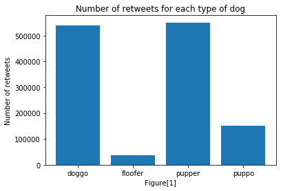

```python
dogs = retweet_count_summtion_by_dog_type.index
h = np.arange(len(dogs))
retweets = retweet_count_summtion_by_dog_type.values

plt.bar(h, retweets)
plt.xticks(h, dogs)
plt.ylabel('Number of retweets')
plt.xlabel('Figure[1]')
plt.title('Number of retweets for each type of dog')

plt.show()
```

#### 2- what's the dog type which have the largest number of retweets in average?

```python
retweet_count_average_by_dog_type[retweet_count_average_by_dog_type.values == retweet_count_average_by_dog_type.max()]
```

```
dog_type
puppo    6332.5
Name: retweet_count, dtype: float64
```

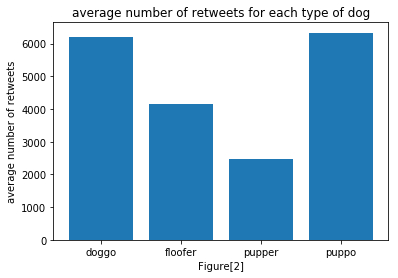

```python
dogs = retweet_count_average_by_dog_type.index
h = np.arange(len(dogs))
retweets = retweet_count_average_by_dog_type.values

plt.bar(h, retweets)
plt.xticks(h, dogs)
plt.ylabel('average number of retweets')
plt.xlabel('Figure[2]')
plt.title('average number of retweets for each type of dog')

plt.show()
```

#### 3- what's the dog type which have the largest number of favorites?

```python
favorite_count_summtion_by_dog_type[favorite_count_summtion_by_dog_type.values == favorite_count_summtion_by_dog_type.max()]
```

```
dog_type
pupper    1607484
Name: favorite_count, dtype: int64
```

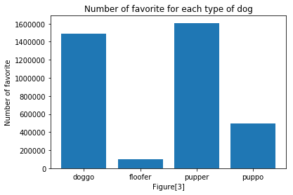

```python
dogs = favorite_count_summtion_by_dog_type.index
h = np.arange(len(dogs))
retweets = favorite_count_summtion_by_dog_type.values

plt.bar(h, retweets)
plt.xticks(h, dogs)
plt.ylabel('Number of favorite')
plt.xlabel('Figure[3]')
plt.title('Number of favorite for each type of dog')

plt.show()
```

#### 4- what's the dog type which have the largest number of favorites in average?

```python
favorite_count_average_by_dog_type[favorite_count_average_by_dog_type.values == favorite_count_average_by_dog_type.max()]
```

```
dog_type
puppo    20788.875
Name: favorite_count, dtype: float64
```

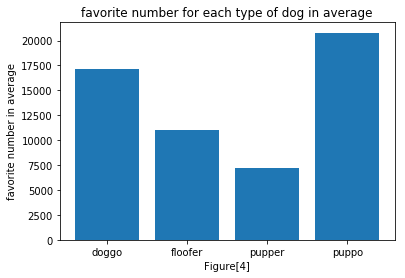

```python
dogs = favorite_count_average_by_dog_type.index
h = np.arange(len(dogs))
retweets = favorite_count_average_by_dog_type.values

plt.bar(h, retweets)
plt.xticks(h, dogs)
plt.ylabel('favorite number in average')
plt.xlabel('Figure[4]')
plt.title('favorite number for each type of dog in average')

plt.show()
```

#### 5- what's the dog type which have the largest rate?

```python
max_rating_numerator_by_dog_type[max_rating_numerator_by_dog_type.values == max_rating_numerator_by_dog_type.max()]
```

```
dog_type
doggo     14.0
pupper    14.0
puppo     14.0
Name: rating_numerator, dtype: float64
```

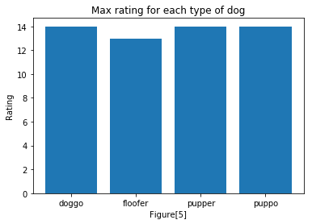

```python
dogs = max_rating_numerator_by_dog_type.index
h = np.arange(len(dogs))
rate = max_rating_numerator_by_dog_type.values

plt.bar(h, rate)
plt.xticks(h, dogs)
plt.ylabel('Rating')
plt.xlabel('Figure[5]')
plt.title('Max rating for each type of dog')

plt.show()
```

#### 6- what's the dog type which have the largest rating in average?

```python
avg_rating_numerator_by_dog_type[avg_rating_numerator_by_dog_type.values == avg_rating_numerator_by_dog_type.max()]
```

```
dog_type
puppo    12.041667
Name: rating_numerator, dtype: float64
```

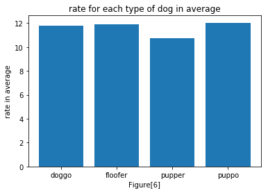

```python
dogs = avg_rating_numerator_by_dog_type.index
h = np.arange(len(dogs))
ratings = avg_rating_numerator_by_dog_type.values

plt.bar(h, ratings)
plt.xticks(h, dogs)
plt.ylabel('rate in average')
plt.xlabel('Figure[6]')
plt.title('rate for each type of dog in average')

plt.show()
```

### Insights:

1- the dog type which have the largest number of retweets is pupper with value = 550530 retweets  
2- the dog type which have the largest number of retweets in average is puppo with value = 6332.5 retweets  
3- the dog type which have the largest number of favorites is pupper with value = 1607484 favorites  
4- the dog type which have the largest number of favorites in average is puppo with value = 20788.875 favorites  
5- the dog type which have the largest rate are doggo = 14.0, pupper = 14.0 and puppo = 14.0  
6- the dog type which have the largest rating in average is puppo with value = 12.041667

- we say that the dog type which has large number of retweets has large number of favorites also.

## Storing

```python
twitter_archive_enhanced_clean.to_csv('twitter_archive_master')
```

## References:

1- The code used to draw bar charts: https://pythonspot.com/matplotlib-bar-chart/  
2- The code used in boolean indexing: https://stackoverflow.com/questions/53413077/python-pandas-remove-duplicate-rows-that-have-a-column-value-nan